# Problem Statement

BrightMarket Retail invests significantly in customer acquisition through various channels, including online and offline advertisements, promotions, and discounts. While these efforts yield high revenue from some customers, others result in negative profitability, adversely affecting overall business performance. The challenge lies in identifying patterns and segmenting customers based on their lifetime value (LTV) to optimize marketing strategies and resource allocation.  
Currently, calculating historical LTV is straightforward but reactive. It often becomes evident too late when customers have already negatively impacted profitability. To address this, BrightMarket Retail needs a proactive approach to predict future LTV, allowing for timely interventions and more strategic decision-making.

# 1. Importing Libraries and Dataset

```python
import warnings
warnings.filterwarnings('ignore')
import numpy as np
import pandas as pd
import seaborn as sns
import matplotlib.pyplot as plt
from scipy.stats import linregress
from sklearn.ensemble import IsolationForest
from matplotlib.colors import LinearSegmentedColormap
```

```python
#Importing Dataset
r_data = pd.read_csv("customer_segmentation.csv", encoding='ISO-8859-1')
```

```python
#Creating copy to work on
df = r_data
```

```python
#Checking dataset
df.head(10)
```

|  | InvoiceNo | StockCode | Description | Quantity | InvoiceDate | UnitPrice | CustomerID | Country |
| --- | --- | --- | --- | --- | --- | --- | --- | --- |
| 0 | 536365 | 85123A | WHITE HANGING HEART T-LIGHT HOLDER | 6 | 12/1/2010 | 2.55 | 17850.0 | United Kingdom |
| 1 | 536365 | 71053 | WHITE METAL LANTERN | 6 | 12/1/2010 | 3.39 | 17850.0 | United Kingdom |
| 2 | 536365 | 84406B | CREAM CUPID HEARTS COAT HANGER | 8 | 12/1/2010 | 2.75 | 17850.0 | United Kingdom |
| 3 | 536365 | 84029G | KNITTED UNION FLAG HOT WATER BOTTLE | 6 | 12/1/2010 | 3.39 | 17850.0 | United Kingdom |
| 4 | 536365 | 84029E | RED WOOLLY HOTTIE WHITE HEART. | 6 | 12/1/2010 | 3.39 | 17850.0 | United Kingdom |
| 5 | 536365 | 22752 | SET 7 BABUSHKA NESTING BOXES | 2 | 12/1/2010 | 7.65 | 17850.0 | United Kingdom |
| 6 | 536365 | 21730 | GLASS STAR FROSTED T-LIGHT HOLDER | 6 | 12/1/2010 | 4.25 | 17850.0 | United Kingdom |
| 7 | 536366 | 22633 | HAND WARMER UNION JACK | 6 | 12/1/2010 | 1.85 | 17850.0 | United Kingdom |
| 8 | 536366 | 22632 | HAND WARMER RED POLKA DOT | 6 | 12/1/2010 | 1.85 | 17850.0 | United Kingdom |
| 9 | 536367 | 84879 | ASSORTED COLOUR BIRD ORNAMENT | 32 | 12/1/2010 | 1.69 | 13047.0 | United Kingdom |

```python
#Checking info
df.info()
```

```
<class 'pandas.core.frame.DataFrame'>
RangeIndex: 541909 entries, 0 to 541908
Data columns (total 8 columns):
 #   Column       Non-Null Count   Dtype
---  ------       --------------   -----
 0   InvoiceNo    541909 non-null  object
 1   StockCode    541909 non-null  object
 2   Description  540455 non-null  object
 3   Quantity     541909 non-null  int64
 4   InvoiceDate  541909 non-null  object
 5   UnitPrice    541909 non-null  float64
 6   CustomerID   406829 non-null  float64
 7   Country      541909 non-null  object
dtypes: float64(2), int64(1), object(5)
memory usage: 33.1+ MB
```

The dataset has 541,909 entries and 8 columns:

The next steps are to clean and prepare the data by handling missing values, fixing any mistakes, and creating new features to help with our analysis.

```python
# Summary statistics for all variables
df.describe(include='all')
```

|  | InvoiceNo | StockCode | Description | Quantity | InvoiceDate | UnitPrice | CustomerID | Country |
| --- | --- | --- | --- | --- | --- | --- | --- | --- |
| count | 541909 | 541909 | 540455 | 541909.000000 | 541909 | 541909.000000 | 406829.000000 | 541909 |
| unique | 25900 | 4070 | 4223 | NaN | 305 | NaN | NaN | 38 |
| top | 573585 | 85123A | WHITE HANGING HEART T-LIGHT HOLDER | NaN | 12/5/2011 | NaN | NaN | United Kingdom |
| freq | 1114 | 2313 | 2369 | NaN | 5331 | NaN | NaN | 495478 |
| mean | NaN | NaN | NaN | 9.552250 | NaN | 4.611114 | 15287.690570 | NaN |
| std | NaN | NaN | NaN | 218.081158 | NaN | 96.759853 | 1713.600303 | NaN |
| min | NaN | NaN | NaN | -80995.000000 | NaN | -11062.060000 | 12346.000000 | NaN |
| 25% | NaN | NaN | NaN | 1.000000 | NaN | 1.250000 | 13953.000000 | NaN |
| 50% | NaN | NaN | NaN | 3.000000 | NaN | 2.080000 | 15152.000000 | NaN |
| 75% | NaN | NaN | NaN | 10.000000 | NaN | 4.130000 | 16791.000000 | NaN |
| max | NaN | NaN | NaN | 80995.000000 | NaN | 38970.000000 | 18287.000000 | NaN |

**Inference:**

Quantity:  
On average, around 9.55 products are purchased per transaction.  
The number of products ranges from -80,995 (returns or cancellations) to 80,995, showing a big difference. The negative numbers need to be handled properly.  
The large difference between the highest value and the 75th percentile suggests there are outliers.

UnitPrice:  
The average price of products is around 4.61.  
Prices range from -11,062.06 to 38,970, indicating possible errors since prices shouldn't be negative.  
Similar to the quantity, there are likely outliers due to the large difference between the highest price and the 75th percentile.

CustomerID:  
There are 406,829 non-null entries, meaning there are missing values that need attention.  
Customer IDs range from 12,346 to 18,287, helping identify unique customers.

InvoiceNo:  
There are 25,900 unique invoices, indicating 25,900 separate transactions.  
The most common invoice number is 573585, appearing 1,114 times, possibly for a large or multi-item order.

Description:  
There are 4,223 unique product descriptions.  
The most common description is "WHITE HANGING HEART T-LIGHT HOLDER," appearing 2,369 times.  
There are some missing product descriptions that need to be addressed.

Country:  
The transactions are from 38 different countries, with about 91.4% of them coming from the United Kingdom.

# 2. DATA CLEANING AND TRANSFORMATION

## 2.0 CHANGING DATA TYPES

```python
df['CustomerID'] = df['CustomerID'].astype('str').replace('nan', pd.NA)
```

## 2.1 MISSING VALUES TREATMENT

Initially the first step is to determine the percentage of missing values present in each column, followed by selecting the most effective strategy to address them.

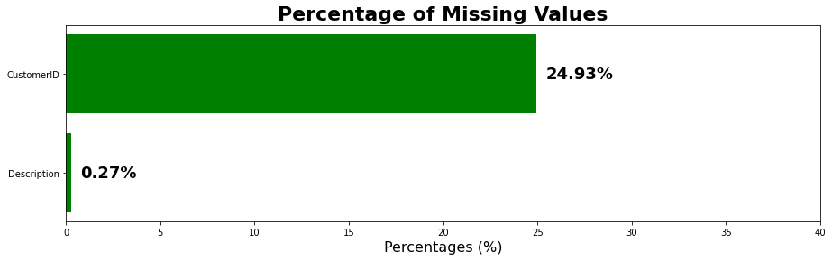

```python
# Calculating the percentage of missing values for each column
missing_data = df.isnull().sum()
missing_percentage = (missing_data[missing_data > 0] / df.shape[0]) * 100

# Prepare values
missing_percentage.sort_values(ascending=True, inplace=True)

# Plot the barh chart
fig, ax = plt.subplots(figsize=(15, 4))
ax.barh(missing_percentage.index, missing_percentage, color='green')

# Annotate the values and indexes
for i, (value, name) in enumerate(zip(missing_percentage, missing_percentage.index)):
    ax.text(value+0.5, i, f"{value:.2f}%", ha='left', va='center', fontweight='bold', fontsize=18, color='black')

# Set x-axis limit
ax.set_xlim([0, 40])

# Add title and xlabel
plt.title("Percentage of Missing Values", fontweight='bold', fontsize=22)
plt.xlabel('Percentages (%)', fontsize=16)
plt.show()
```

**Missing Value Treatment Strategy**

CustomerID (24.93% missing values):  
The CustomerID column has almost a quarter of its values missing. Since CustomerID is crucial for identifying customers and creating recommendations, filling in these missing values could lead to errors.  
Therefore, the best approach is to remove rows with missing CustomerIDs to ensure accurate analysis.

#### 2.1.1 Treating Null Values in 'Description' Column

```python
#Checking sum of null values in Description column
df['Description'].isnull().sum().sum()
```

```
1454
```

One way to efficiently perform the missing value treatment in case of Description column is to map the description of the product to the stock code present in the adjacent column. If there are remaining rows with null values in the Description column, they can further be treated in other methods.

```python
#Identify rows with missing descriptions
missing_description_df = df[df['Description'].isnull()]

#Create a mapping of Stock Code to Description from rows with available descriptions
stock_code_to_description = df.dropna(subset=['Description']).drop_duplicates('StockCode').set_index('StockCode')['Description']

#Fill missing descriptions using the mapping
df['Description'] = df['StockCode'].map(stock_code_to_description).combine_first(df['Description'])

# Display the updated dataframe
print(df)
```

```
       InvoiceNo StockCode                          Description  Quantity  \
0         536365    85123A   WHITE HANGING HEART T-LIGHT HOLDER         6
1         536365     71053                  WHITE METAL LANTERN         6
2         536365    84406B       CREAM CUPID HEARTS COAT HANGER         8
3         536365    84029G  KNITTED UNION FLAG HOT WATER BOTTLE         6
4         536365    84029E       RED WOOLLY HOTTIE WHITE HEART.         6
...          ...       ...                                  ...       ...
541904    581587     22613          PACK OF 20 SPACEBOY NAPKINS        12
541905    581587     22899         CHILDREN'S APRON DOLLY GIRL          6
541906    581587     23254        CHILDRENS CUTLERY DOLLY GIRL          4
541907    581587     23255      CHILDRENS CUTLERY CIRCUS PARADE         4
541908    581587     22138        BAKING SET 9 PIECE RETROSPOT          3

       InvoiceDate  UnitPrice CustomerID         Country
0        12/1/2010       2.55    17850.0  United Kingdom
1        12/1/2010       3.39    17850.0  United Kingdom
2        12/1/2010       2.75    17850.0  United Kingdom
3        12/1/2010       3.39    17850.0  United Kingdom
4        12/1/2010       3.39    17850.0  United Kingdom
...            ...        ...        ...             ...
541904   12/9/2011       0.85    12680.0          France
541905   12/9/2011       2.10    12680.0          France
541906   12/9/2011       4.15    12680.0          France
541907   12/9/2011       4.15    12680.0          France
541908   12/9/2011       4.95    12680.0          France

[541909 rows x 8 columns]
```

```python
# Verifying the removal of missing values
df['Description'].isnull().sum().sum()
```

```
112
```

#### 2.1.2 Null Values Extraction

```python
# Extracting rows with missing values in 'CustomerID' or 'Description' columns into df_null
df_null = df[df['CustomerID'].isnull() | df['Description'].isnull()]
```

```python
#Displaying null value rows
df_null.head(20)
```

|  | InvoiceNo | StockCode | Description | Quantity | InvoiceDate | UnitPrice | CustomerID | Country |
| --- | --- | --- | --- | --- | --- | --- | --- | --- |
| 622 | 536414 | 22139 | RETROSPOT TEA SET CERAMIC 11 PC | 56 | 12/1/2010 | 0.00 | <NA> | United Kingdom |
| 1443 | 536544 | 21773 | DECORATIVE ROSE BATHROOM BOTTLE | 1 | 12/1/2010 | 2.51 | <NA> | United Kingdom |
| 1444 | 536544 | 21774 | DECORATIVE CATS BATHROOM BOTTLE | 2 | 12/1/2010 | 2.51 | <NA> | United Kingdom |
| 1445 | 536544 | 21786 | POLKADOT RAIN HAT | 4 | 12/1/2010 | 0.85 | <NA> | United Kingdom |
| 1446 | 536544 | 21787 | RAIN PONCHO RETROSPOT | 2 | 12/1/2010 | 1.66 | <NA> | United Kingdom |
| 1447 | 536544 | 21790 | VINTAGE SNAP CARDS | 9 | 12/1/2010 | 1.66 | <NA> | United Kingdom |
| 1448 | 536544 | 21791 | VINTAGE HEADS AND TAILS CARD GAME | 2 | 12/1/2010 | 2.51 | <NA> | United Kingdom |
| 1449 | 536544 | 21801 | CHRISTMAS TREE DECORATION WITH BELL | 10 | 12/1/2010 | 0.43 | <NA> | United Kingdom |
| 1450 | 536544 | 21802 | CHRISTMAS TREE HEART DECORATION | 9 | 12/1/2010 | 0.43 | <NA> | United Kingdom |
| 1451 | 536544 | 21803 | CHRISTMAS TREE STAR DECORATION | 11 | 12/1/2010 | 0.43 | <NA> | United Kingdom |
| 1452 | 536544 | 21809 | CHRISTMAS HANGING TREE WITH BELL | 1 | 12/1/2010 | 2.51 | <NA> | United Kingdom |
| 1453 | 536544 | 21810 | CHRISTMAS HANGING STAR WITH BELL | 3 | 12/1/2010 | 2.51 | <NA> | United Kingdom |
| 1454 | 536544 | 21811 | CHRISTMAS HANGING HEART WITH BELL | 1 | 12/1/2010 | 2.51 | <NA> | United Kingdom |
| 1455 | 536544 | 21821 | GLITTER STAR GARLAND WITH BELLS | 1 | 12/1/2010 | 7.62 | <NA> | United Kingdom |
| 1456 | 536544 | 21822 | GLITTER CHRISTMAS TREE WITH BELLS | 1 | 12/1/2010 | 4.21 | <NA> | United Kingdom |
| 1457 | 536544 | 21823 | PAINTED METAL HEART WITH HOLLY BELL | 2 | 12/1/2010 | 2.98 | <NA> | United Kingdom |
| 1458 | 536544 | 21844 | RED RETROSPOT MUG | 2 | 12/1/2010 | 5.91 | <NA> | United Kingdom |
| 1459 | 536544 | 21851 | LILAC DIAMANTE PEN IN GIFT BOX | 1 | 12/1/2010 | 4.21 | <NA> | United Kingdom |
| 1460 | 536544 | 21870 | I CAN ONLY PLEASE ONE PERSON MUG | 1 | 12/1/2010 | 3.36 | <NA> | United Kingdom |
| 1461 | 536544 | 21871 | SAVE THE PLANET MUG | 5 | 12/1/2010 | 3.36 | <NA> | United Kingdom |

```python
# Removing rows with missing values in 'CustomerID' and 'Description' columns
df_removed = df.dropna(subset=['CustomerID', 'Description'])
```

#### 2.1.3 Null Value Analysis

```python
#Displaying table with null value rows
df_null.describe(include="all")
```

|  | InvoiceNo | StockCode | Description | Quantity | InvoiceDate | UnitPrice | CustomerID | Country |
| --- | --- | --- | --- | --- | --- | --- | --- | --- |
| count | 135080 | 135080 | 134968 | 135080.000000 | 135080 | 135080.000000 | 0 | 135080 |
| unique | 3710 | 3810 | 3563 | NaN | 277 | NaN | 0 | 9 |
| top | 573585 | DOT | DOTCOM POSTAGE | NaN | 8/30/2011 | NaN | NaN | United Kingdom |
| freq | 1114 | 694 | 694 | NaN | 2829 | NaN | NaN | 133600 |
| mean | NaN | NaN | NaN | 1.995573 | NaN | 8.076577 | NaN | NaN |
| std | NaN | NaN | NaN | 66.696153 | NaN | 151.900816 | NaN | NaN |
| min | NaN | NaN | NaN | -9600.000000 | NaN | -11062.060000 | NaN | NaN |
| 25% | NaN | NaN | NaN | 1.000000 | NaN | 1.630000 | NaN | NaN |
| 50% | NaN | NaN | NaN | 1.000000 | NaN | 3.290000 | NaN | NaN |
| 75% | NaN | NaN | NaN | 3.000000 | NaN | 5.450000 | NaN | NaN |
| max | NaN | NaN | NaN | 5568.000000 | NaN | 17836.460000 | NaN | NaN |

Now, the problem arises is that our CustomerID column consists of nearly 25% null values, which is 1/4th of our data. Before removing these values or imputing them we must understand if or how the dataset has changed after removing the null values.

```python
# Skewness for each numerical column in df_removed
skewness_df_removed = df_removed.select_dtypes(include=['number']).skew()

# Skewness for each numerical column in df
skewness_df = df.select_dtypes(include=['number']).skew()

skewness_df_removed, skewness_df
```

```
(Quantity       0.182663
 UnitPrice    452.219019
 dtype: float64,
 Quantity      -0.264076
 UnitPrice    186.506972
 dtype: float64)
```

For the two columns: 'Quantity' and 'UnitPrice' where skewness differs, it indicates that the removal of null values has altered the distribution of data. This could suggest that the null values were not randomly distributed and that the data may have been biased or imbalanced in some way. The change in skewness could imply that the underlying distribution of these columns has been affected, potentially leading to different insights or model behavior.

```python
from scipy.stats import ttest_ind

# Perform t-test on UnitPrice
column = 'UnitPrice'
t_stat, p_value = ttest_ind(df[column], df_removed[column].dropna())

t_stat, p_value
```

```
(6.444449959564247, 1.1607566201433936e-10)
```

```python
from scipy.stats import ttest_ind

# Perform t-test on UnitPrice
column = 'Quantity'
t_stat, p_value = ttest_ind(df[column], df_removed[column].dropna())

t_stat, p_value
```

```
(-5.220027033211611, 1.7893455322625746e-07)
```

The results of the t-test indicate that the means of the original dataset (non-NaN values) and the null-free dataset are significantly different. This suggests that the removal of NaN values has had a substantial impact on the data, and we cannot assume that the datasets are equivalent after removing the missing values.

#### 2.1.4 Null Value Treatment

This necessarily means that we cannot simply remove the rows with null values but instead we must impute them somehow. Since, the column with most missing values is CustomerID, we cannot simply use ffill or bfill because our data is not present in a time series format, one way to go about it would be to identify all non-CustomerID transactions to be recorded as 'Unregistered' as it happens quite often that a customer purchases an item but they are not registered to the business' account.

```python
#Replace NaN values in 'CustomerID' column with 'unregistered'
specified_value = 'unregistered'
df['CustomerID'].fillna(value=specified_value, inplace=True)
```

```python
#Checking Null Values
df.isna().sum()
```

```
InvoiceNo        0
StockCode        0
Description    112
Quantity         0
InvoiceDate      0
UnitPrice        0
CustomerID       0
Country          0
dtype: int64
```

The remaining null values constitute a very small percentage of the dataset, close to 0.02%. Thus, we can remove these null values without it resulting in changing the structure of the data.

```python
# Removing rows with missing values in 'Description' columns
df = df.dropna(subset=['Description'])
```

```python
#Checking Null Values
df.isna().sum().sum()
```

```
0
```

## 2.2 DUPLICATE VALUES TREATMENT

The first step is to identify the duplicate rows in the dataset.

```python
# Finding duplicate rows (keeping all instances)
duplicate_rows = df[df.duplicated(keep=False)]

# Sorting the data by certain columns to see the duplicate rows next to each other
duplicate_rows_sorted = duplicate_rows.sort_values(by=['InvoiceNo', 'StockCode', 'Description', 'InvoiceDate', 'UnitPrice', 'CustomerID', 'Quantity', 'Country'])

# Displaying the first 10 records
duplicate_rows_sorted.head(10)
```

|  | InvoiceNo | StockCode | Description | Quantity | InvoiceDate | UnitPrice | CustomerID | Country |
| --- | --- | --- | --- | --- | --- | --- | --- | --- |
| 494 | 536409 | 21866 | UNION JACK FLAG LUGGAGE TAG | 1 | 12/1/2010 | 1.25 | 17908.0 | United Kingdom |
| 517 | 536409 | 21866 | UNION JACK FLAG LUGGAGE TAG | 1 | 12/1/2010 | 1.25 | 17908.0 | United Kingdom |
| 485 | 536409 | 22111 | SCOTTIE DOG HOT WATER BOTTLE | 1 | 12/1/2010 | 4.95 | 17908.0 | United Kingdom |
| 539 | 536409 | 22111 | SCOTTIE DOG HOT WATER BOTTLE | 1 | 12/1/2010 | 4.95 | 17908.0 | United Kingdom |
| 489 | 536409 | 22866 | HAND WARMER SCOTTY DOG DESIGN | 1 | 12/1/2010 | 2.10 | 17908.0 | United Kingdom |
| 527 | 536409 | 22866 | HAND WARMER SCOTTY DOG DESIGN | 1 | 12/1/2010 | 2.10 | 17908.0 | United Kingdom |
| 521 | 536409 | 22900 | SET 2 TEA TOWELS I LOVE LONDON | 1 | 12/1/2010 | 2.95 | 17908.0 | United Kingdom |
| 537 | 536409 | 22900 | SET 2 TEA TOWELS I LOVE LONDON | 1 | 12/1/2010 | 2.95 | 17908.0 | United Kingdom |
| 578 | 536412 | 21448 | 12 DAISY PEGS IN WOOD BOX | 1 | 12/1/2010 | 1.65 | 17920.0 | United Kingdom |
| 598 | 536412 | 21448 | 12 DAISY PEGS IN WOOD BOX | 1 | 12/1/2010 | 1.65 | 17920.0 | United Kingdom |

**Duplicates Handling strategy**

In this project, having completely identical rows, including the same transaction times, likely means there are data recording errors rather than actual repeated transactions. Keeping these duplicates could mess up the analysis and recommendations.

So, we'll remove these exact duplicate rows from the dataset. This will help clean the data and make it easier to accurately identify unique customer behaviors and the most purchased products. It will also help us build a better recommendation system.

```python
# Displaying the number of duplicate rows
print(f"The dataset contains {df.duplicated().sum()} duplicate rows that need to be removed.")

# Removing duplicate rows
df.drop_duplicates(inplace=True)
```

```
The dataset contains 5271 duplicate rows that need to be removed.
```

```python
# Getting the number of rows in the dataframe
df.shape[0]
```

```
536526
```

## 2.3 CANCELLED TRANSACTIONS TREATMENT

To better understand customer behavior and preferences, we need to look at cancelled transactions. First, we'll find these transactions by looking for invoice numbers that start with "C". Then, we'll analyze these cancelled transactions to find common patterns or features.

```python
# Filter out the rows with InvoiceNo starting with "C" and create a new column indicating the transaction status
df['Transaction_Status'] = np.where(df['InvoiceNo'].astype(str).str.startswith('C'), 'Cancelled', 'Completed')

# Analyze the characteristics of these rows (considering the new column)
cancelled_transactions = df[df['Transaction_Status'] == 'Cancelled']
cancelled_transactions.describe(include="all")
```

|  | InvoiceNo | StockCode | Description | Quantity | InvoiceDate | UnitPrice | CustomerID | Country | Transaction_Status |
| --- | --- | --- | --- | --- | --- | --- | --- | --- | --- |
| count | 9251 | 9251 | 9251 | 9251.000000 | 9251 | 9251.000000 | 9251 | 9251 | 9251 |
| unique | 3836 | 1947 | 1940 | NaN | 302 | NaN | 1590 | 30 | 1 |
| top | C570867 | M | Manual | NaN | 10/6/2011 | NaN | unregistered | United Kingdom | Cancelled |
| freq | 101 | 244 | 244 | NaN | 227 | NaN | 379 | 7821 | 9251 |
| mean | NaN | NaN | NaN | -29.787050 | NaN | 48.570430 | NaN | NaN | NaN |
| std | NaN | NaN | NaN | 1147.997592 | NaN | 667.926393 | NaN | NaN | NaN |
| min | NaN | NaN | NaN | -80995.000000 | NaN | 0.010000 | NaN | NaN | NaN |
| 25% | NaN | NaN | NaN | -6.000000 | NaN | 1.450000 | NaN | NaN | NaN |
| 50% | NaN | NaN | NaN | -2.000000 | NaN | 2.950000 | NaN | NaN | NaN |
| 75% | NaN | NaN | NaN | -1.000000 | NaN | 5.950000 | NaN | NaN | NaN |
| max | NaN | NaN | NaN | -1.000000 | NaN | 38970.000000 | NaN | NaN | NaN |

All the quantities in the cancelled transactions are negative, confirming they were cancelled orders. The UnitPrice column shows a wide range of values, meaning cancelled transactions included both low and high-priced products.

**Strategy:**

To improve customer clustering and the recommendation system, we need to understand cancellation patterns. So, we'll keep the cancelled transactions in the dataset but mark them clearly. This will:

Help us see patterns in cancellations, which might show specific customer behaviors or preferences, and  
Let the recommendation system avoid suggesting products that are likely to be cancelled, making the recommendations better.

```python
# Finding the percentage of cancelled transactions
cancelled_percentage = (cancelled_transactions.shape[0] / df.shape[0]) * 100

# Printing the percentage of cancelled transactions
print(f"The percentage of cancelled transactions in the dataset is: {cancelled_percentage:.2f}%")
```

```
The percentage of cancelled transactions in the dataset is: 1.72%
```

#### 2.3.1 Cancelled Transactions Analysis

```python
cancelled_transactions.head()
```

|  | InvoiceNo | StockCode | Description | Quantity | InvoiceDate | UnitPrice | CustomerID | Country | Transaction_Status |
| --- | --- | --- | --- | --- | --- | --- | --- | --- | --- |
| 141 | C536379 | D | Discount | -1 | 12/1/2010 | 27.50 | 14527.0 | United Kingdom | Cancelled |
| 154 | C536383 | 35004C | SET OF 3 COLOURED FLYING DUCKS | -1 | 12/1/2010 | 4.65 | 15311.0 | United Kingdom | Cancelled |
| 235 | C536391 | 22556 | PLASTERS IN TIN CIRCUS PARADE | -12 | 12/1/2010 | 1.65 | 17548.0 | United Kingdom | Cancelled |
| 236 | C536391 | 21984 | PACK OF 12 PINK PAISLEY TISSUES | -24 | 12/1/2010 | 0.29 | 17548.0 | United Kingdom | Cancelled |
| 237 | C536391 | 21983 | PACK OF 12 BLUE PAISLEY TISSUES | -24 | 12/1/2010 | 0.29 | 17548.0 | United Kingdom | Cancelled |

```python
cancelled_transactions.describe(include="all")
```

|  | InvoiceNo | StockCode | Description | Quantity | InvoiceDate | UnitPrice | CustomerID | Country | Transaction_Status |
| --- | --- | --- | --- | --- | --- | --- | --- | --- | --- |
| count | 9251 | 9251 | 9251 | 9251.000000 | 9251 | 9251.000000 | 9251 | 9251 | 9251 |
| unique | 3836 | 1947 | 1940 | NaN | 302 | NaN | 1590 | 30 | 1 |
| top | C570867 | M | Manual | NaN | 10/6/2011 | NaN | unregistered | United Kingdom | Cancelled |
| freq | 101 | 244 | 244 | NaN | 227 | NaN | 379 | 7821 | 9251 |
| mean | NaN | NaN | NaN | -29.787050 | NaN | 48.570430 | NaN | NaN | NaN |
| std | NaN | NaN | NaN | 1147.997592 | NaN | 667.926393 | NaN | NaN | NaN |
| min | NaN | NaN | NaN | -80995.000000 | NaN | 0.010000 | NaN | NaN | NaN |
| 25% | NaN | NaN | NaN | -6.000000 | NaN | 1.450000 | NaN | NaN | NaN |
| 50% | NaN | NaN | NaN | -2.000000 | NaN | 2.950000 | NaN | NaN | NaN |
| 75% | NaN | NaN | NaN | -1.000000 | NaN | 5.950000 | NaN | NaN | NaN |
| max | NaN | NaN | NaN | -1.000000 | NaN | 38970.000000 | NaN | NaN | NaN |

```python
# Group by CustomerID to check for recurring cancellations
recurring_cancellations = cancelled_transactions.groupby('CustomerID').size().reset_index(name='Cancellation_Count')

# Filter to find customers with multiple cancellations
recurring_cancellations = recurring_cancellations[recurring_cancellations['Cancellation_Count'] > 1]

print(recurring_cancellations)
```

```
        CustomerID  Cancellation_Count
1          12352.0                  10
2          12359.0                   6
3          12362.0                   8
8          12381.0                   4
10         12384.0                   3
...            ...                 ...
1583       18270.0                   2
1584       18272.0                   4
1585       18274.0                  11
1586       18276.0                   2
1589  unregistered                 379

[1086 rows x 2 columns]
```

```python
# Identify most frequently canceled products
cancelled_products = cancelled_transactions['StockCode'].value_counts().reset_index(name='Cancellation_Count')
cancelled_products.columns = ['StockCode', 'Cancellation_Count']

print(cancelled_products.head())
```

```
  StockCode  Cancellation_Count
0         M                 244
1     22423                 180
2      POST                 126
3     22960                  87
4         D                  77
```

```python
# Investigate specific product cancellation reasons
specific_product_analysis = cancelled_transactions[cancelled_transactions['StockCode'].isin(['M'])]
print(specific_product_analysis.describe())
```

```
          Quantity     UnitPrice
count   244.000000    244.000000
mean    -16.663934    575.172869
std     101.237862   2598.121378
min   -1350.000000      0.030000
25%      -1.000000      5.362500
50%      -1.000000    120.290000
75%      -1.000000    453.137500
max      -1.000000  38970.000000
```

```python
# Investigate specific product cancellation reasons
specific_product_analysis = cancelled_transactions[cancelled_transactions['StockCode'].isin(['22423'])]
print(specific_product_analysis.describe())
```

```
         Quantity   UnitPrice
count  180.000000  180.000000
mean    -4.750000   11.980000
std     12.517641    0.893046
min   -150.000000   10.950000
25%     -4.000000   10.950000
50%     -1.000000   12.750000
75%     -1.000000   12.750000
max     -1.000000   12.750000
```

```python
# Investigate specific product cancellation reasons
specific_product_analysis = cancelled_transactions[cancelled_transactions['StockCode'].isin(['POST'])]
print(specific_product_analysis.describe())
```

```
         Quantity    UnitPrice
count  126.000000   126.000000
mean    -1.166667    90.446349
std      0.517687   725.331214
min     -4.000000     1.000000
25%     -1.000000     4.500000
50%     -1.000000    15.000000
75%     -1.000000    22.365000
max     -1.000000  8142.750000
```

```python
# Investigate specific product cancellation reasons
specific_product_analysis = cancelled_transactions[cancelled_transactions['StockCode'].isin(['22960'])]
print(specific_product_analysis.describe())
```

```
        Quantity  UnitPrice
count  87.000000  87.000000
mean   -2.839080   4.204483
std     2.790655   0.483944
min   -12.000000   3.750000
25%    -3.000000   4.250000
50%    -2.000000   4.250000
75%    -1.000000   4.250000
max    -1.000000   8.290000
```

```python
# Investigate specific product cancellation reasons
specific_product_analysis = cancelled_transactions[cancelled_transactions['StockCode'].isin(['D'])]
print(specific_product_analysis.describe())
```

```
         Quantity    UnitPrice
count   77.000000    77.000000
mean   -15.506494    72.484545
std     86.557043   219.271071
min   -720.000000     0.010000
25%     -1.000000    13.880000
50%     -1.000000    22.970000
75%     -1.000000    57.600000
max     -1.000000  1867.860000
```

We are able to observe that in all the cases in an instance the maximum value of quantity has always been less than 0 which could mean that the product in itself must have always been cancelled which could be due to reasons such as its varying price ranges and not due to customers who are cancelling the products.

## 2.4 STOCK CODE ANOMALIES CORRECTION

Initially, we must find the number of unique stock codes and plot the top 10 most frequent stock codes along with their percentage frequency.

```python
# Finding the number of unique stock codes
unique_stock_codes = df['StockCode'].nunique()

# Printing the number of unique stock codes
print(f"The number of unique stock codes in the dataset is: {unique_stock_codes}")
```

```
The number of unique stock codes in the dataset is: 3958
```

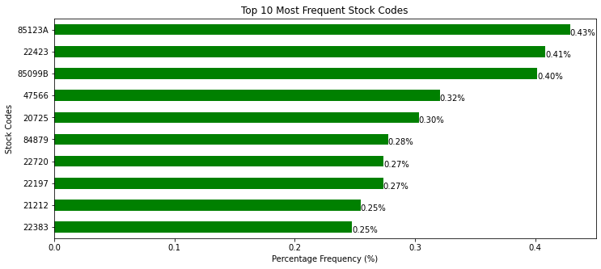

```python
# Finding the top 10 most frequent stock codes
top_10_stock_codes = df['StockCode'].value_counts(normalize=True).head(10) * 100

# Plotting the top 10 most frequent stock codes
plt.figure(figsize=(12, 5))
top_10_stock_codes.plot(kind='barh', color='green')

# Adding the percentage frequency on the bars
for index, value in enumerate(top_10_stock_codes):
    plt.text(value, index+0.25, f'{value:.2f}%', fontsize=10)

plt.title('Top 10 Most Frequent Stock Codes')
plt.xlabel('Percentage Frequency (%)')
plt.ylabel('Stock Codes')
plt.gca().invert_yaxis()
plt.show()
```

Popular Items: Looking at the top 10 most frequent stock codes can give us insight into which products or categories are most popular among customers.

Stock Code Anomalies: Most stock codes have 5 or 6 characters, but some, like 'POST', are different. These might represent services or non-product transactions (like postage fees) rather than actual products. Since we're focusing on clustering based on product purchases and creating a recommendation system, we should investigate these anomalies and handle them appropriately to keep the data accurate.

To delve deeper into identifying these anomalies, we explore the frequency of the number of numeric characters in the stock codes, which can provide insights into the nature of these unusual entries.

```python
# Finding the number of numeric characters in each unique stock code
unique_stock_codes = df['StockCode'].unique()
numeric_char_counts_in_unique_codes = pd.Series(unique_stock_codes).apply(lambda x: sum(c.isdigit() for c in str(x))).value_counts()

# Printing the value counts for unique stock codes
print("Value counts of numeric character frequencies in unique stock codes:")
print("-"*70)
print(numeric_char_counts_in_unique_codes)
```

```
Value counts of numeric character frequencies in unique stock codes:
----------------------------------------------------------------------
5    3931
0      13
4       8
6       5
1       1
Name: count, dtype: int64
```

The output shows that most stock codes (3,931 out of 3,958) have exactly 5 numeric characters, which seems to be the standard format for product codes in this dataset.

However, there are a few exceptions: 13 stock codes have no numeric characters, and 1 stock code has only 1 numeric character. These don't follow the usual format and need further investigation to see if they represent valid product transactions.

Next, we'll identify these unusual stock codes to understand them better.

```python
# Finding and printing the stock codes with 0 and 1 numeric characters
anomalous_stock_codes = [code for code in unique_stock_codes if sum(c.isdigit() for c in str(code)) in (0, 1)]

# Printing each stock code on a new line
print("Anomalous stock codes:")
print("-"*22)
for code in anomalous_stock_codes:
    print(code)
```

```
Anomalous stock codes:
----------------------
POST
D
C2
DOT
M
BANK CHARGES
S
AMAZONFEE
m
DCGSSBOY
DCGSSGIRL
PADS
B
CRUK
```

```python
# Calculating the percentage of records with these stock codes
percentage_anomalous = (df['StockCode'].isin(anomalous_stock_codes).sum() / len(df)) * 100

# Printing the percentage
print(f"The percentage of records with anomalous stock codes in the dataset is: {percentage_anomalous:.2f}%")
```

```
The percentage of records with anomalous stock codes in the dataset is: 0.55%
```

The analysis shows that only 0.55% of the records have unusual stock codes that don't match the usual format. These codes are a tiny part of all the unique stock codes (just 14 out of 3,958).

These unusual codes seem to represent things like "BANK CHARGES" or "POST" (possibly postage fees), not actual products. Since they're such a small part of the dataset and don't represent products, including them in the analysis could cause confusion and mess up the clustering and recommendation system.

**Strategy:**

Since the project aims to group customers based on their product purchases and create a recommendation system, it's best to exclude records with unusual stock codes. These codes don't represent real products and could affect the accuracy of our analysis.

So, we should remove rows with these unusual stock codes from the dataset before we continue with the analysis and building the model, but before that we should first check all the stock codes and what do they represent.

```python
#Creating a sepearate dataset which has the rows with anomolous stock codes
df_ano_stock = df[df['StockCode'].isin(anomalous_stock_codes)]
```

#### 2.4.1 Anomolous Stock Codes Analysis

```python
df_ano_stock
```

|  | InvoiceNo | StockCode | Description | Quantity | InvoiceDate | UnitPrice | CustomerID | Country | Transaction_Status |
| --- | --- | --- | --- | --- | --- | --- | --- | --- | --- |
| 45 | 536370 | POST | POSTAGE | 3 | 12/1/2010 | 18.00 | 12583.0 | France | Completed |
| 141 | C536379 | D | Discount | -1 | 12/1/2010 | 27.50 | 14527.0 | United Kingdom | Cancelled |
| 386 | 536403 | POST | POSTAGE | 1 | 12/1/2010 | 15.00 | 12791.0 | Netherlands | Completed |
| 1123 | 536527 | POST | POSTAGE | 1 | 12/1/2010 | 18.00 | 12662.0 | Germany | Completed |
| 1423 | 536540 | C2 | CARRIAGE | 1 | 12/1/2010 | 50.00 | 14911.0 | EIRE | Completed |
| ... | ... | ... | ... | ... | ... | ... | ... | ... | ... |
| 541540 | 581498 | DOT | DOTCOM POSTAGE | 1 | 12/9/2011 | 1714.17 | unregistered | United Kingdom | Completed |
| 541541 | C581499 | M | Manual | -1 | 12/9/2011 | 224.69 | 15498.0 | United Kingdom | Cancelled |
| 541730 | 581570 | POST | POSTAGE | 1 | 12/9/2011 | 18.00 | 12662.0 | Germany | Completed |
| 541767 | 581574 | POST | POSTAGE | 2 | 12/9/2011 | 18.00 | 12526.0 | Germany | Completed |
| 541768 | 581578 | POST | POSTAGE | 3 | 12/9/2011 | 18.00 | 12713.0 | Germany | Completed |

2934 rows × 9 columns

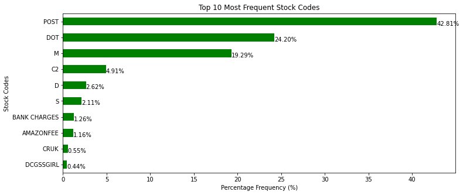

```python
# Finding the top 10 most frequent stock codes
top_10_stock_codes = df_ano_stock['StockCode'].value_counts(normalize=True).head(10) * 100

# Plotting the top 10 most frequent stock codes
plt.figure(figsize=(12, 5))
top_10_stock_codes.plot(kind='barh', color='green')

# Adding the percentage frequency on the bars
for index, value in enumerate(top_10_stock_codes):
    plt.text(value, index+0.25, f'{value:.2f}%', fontsize=10)

plt.title('Top 10 Most Frequent Stock Codes')
plt.xlabel('Percentage Frequency (%)')
plt.ylabel('Stock Codes')
plt.gca().invert_yaxis()
plt.show()
```

```python
#Function to get description of the specific stock code
def analyze_stock_codes(df, stock_codes):

    analysis_results = {}

    for code in stock_codes:
        specific_product_analysis = df[df['StockCode'].isin([code])]
        unique_descriptions = specific_product_analysis['Description'].unique()
        analysis_results[code] = unique_descriptions

    return analysis_results

# Stock Codes
stock_codes_to_analyze = ['POST', 'D', 'DOT', 'C2', 'M', 'BANK CHARGES', 'S', 'AMAZONFEE', 'DCGSSBOY', 'DCGSSGIRL','PADS','B','CRUK']
analysis_results = analyze_stock_codes(df_ano_stock, stock_codes_to_analyze)

# Printing the results
for stock_code, descriptions in analysis_results.items():
    print(f"StockCode: {stock_code}")
    print("Descriptions:", descriptions)
    print("\n")
```

```
StockCode: POST
Descriptions: ['POSTAGE']


StockCode: D
Descriptions: ['Discount']


StockCode: DOT
Descriptions: ['DOTCOM POSTAGE']


StockCode: C2
Descriptions: ['CARRIAGE']


StockCode: M
Descriptions: ['Manual']


StockCode: BANK CHARGES
Descriptions: ['Bank Charges']


StockCode: S
Descriptions: ['SAMPLES']


StockCode: AMAZONFEE
Descriptions: ['AMAZON FEE']


StockCode: DCGSSBOY
Descriptions: ['BOYS PARTY BAG']


StockCode: DCGSSGIRL
Descriptions: ['GIRLS PARTY BAG']


StockCode: PADS
Descriptions: ['PADS TO MATCH ALL CUSHIONS']


StockCode: B
Descriptions: ['Adjust bad debt']


StockCode: CRUK
Descriptions: ['CRUK Commission']
```

From this we understand that certain codes like DCGSSGIRL, DCGSSBOY and PADS are to not be removed from the dataset even if the stock code is an anomoly because these column are important for our analysis.

```python
#Excluding stock codes which are to be mentioned in the analysis
anomalous_stock_codes.remove('DCGSSBOY')
anomalous_stock_codes.remove('DCGSSGIRL')
anomalous_stock_codes.remove('PADS')
```

```python
anomalous_stock_codes
```

```
['POST',
 'D',
 'C2',
 'DOT',
 'M',
 'BANK CHARGES',
 'S',
 'AMAZONFEE',
 'm',
 'B',
 'CRUK']
```

```python
# Removing rows with anomalous stock codes from the dataset
df = df[~df['StockCode'].isin(anomalous_stock_codes)]

# Getting the number of rows in the dataframe
df.shape[0]
```

```
533620
```

## 2.5 DESCRIPTION COLUMN CLEANING

Initially, we need to calculate the occurrence count of each unique description in the dataset. Then, we will plot the top 30 descriptions. This visualization will give us a clear view of the highest occurring descriptions in the dataset.

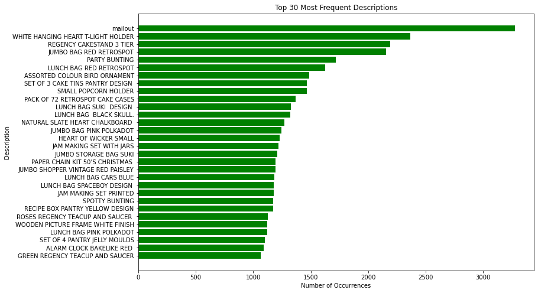

```python
# Calculate the occurrence of each unique description and sort them
description_counts = df['Description'].value_counts()

# Get the top 30 descriptions
top_30_descriptions = description_counts[:30]

# Plotting
plt.figure(figsize=(12,8))
plt.barh(top_30_descriptions.index[::-1], top_30_descriptions.values[::-1], color='green')

# Adding labels and title
plt.xlabel('Number of Occurrences')
plt.ylabel('Description')
plt.title('Top 30 Most Frequent Descriptions')

# Show the plot
plt.show()
```

The most common product descriptions are mostly household items like kitchenware, lunch bags, and decorative things.

```python
# Find unique descriptions containing lowercase characters
lowercase_descriptions = df['Description'].unique()
lowercase_descriptions = [desc for desc in lowercase_descriptions if any(char.islower() for char in desc)]

# Print the unique descriptions containing lowercase characters
print("The unique descriptions containing lowercase characters are:")
print("-"*60)
for desc in lowercase_descriptions:
    print(desc)
```

```
The unique descriptions containing lowercase characters are:
------------------------------------------------------------
BAG 500g SWIRLY MARBLES
POLYESTER FILLER PAD 45x45cm
BAG 125g SWIRLY MARBLES
BAG 250g SWIRLY MARBLES
POLYESTER FILLER PAD 45x30cm
POLYESTER FILLER PAD 40x40cm
FRENCH BLUE METAL DOOR SIGN No
Dr. Jam's Arouzer Stress Ball
NUMBER TILE COTTAGE GARDEN No
FOLK ART GREETING CARD,pack/12
ESSENTIAL BALM 3.5g TIN IN ENVELOPE
POLYESTER FILLER PAD 65CMx65CM
check
Dad's Cab Electronic Meter
NUMBER TILE VINTAGE FONT No
*Boombox Ipod Classic
*USB Office Mirror Ball
POLYESTER FILLER PAD 30CMx30CM
Dotcomgiftshop Gift Voucher £40.00
Dotcomgiftshop Gift Voucher £50.00
Dotcomgiftshop Gift Voucher £30.00
Dotcomgiftshop Gift Voucher £20.00
damages
Given away
thrown away
Dotcomgiftshop Gift Voucher £10.00
throw away
thrown away-can't sell.
thrown away-can't sell
POLYESTER FILLER PAD 60x40cm
mailout
mailout
Thrown away-rusty
FLOWERS HANDBAG blue and orange
Next Day Carriage
wet damaged
Damaged
alan hodge cant mamage this section
ebay
Dotcomgiftshop Gift Voucher £100.00
found
High Resolution Image
adjustment
Found by jackie
Unsaleable, destroyed.
```

When we looked at descriptions with lowercase letters, we found some that aren't actual product descriptions, like "Next Day Carriage" and "High Resolution Image." These seem to be about other information or services, not products.

**Strategy:**

Step 1: Remove rows with descriptions like "Next Day Carriage","High Resolution Image","throw away", "Given away", "thrown away", "thrown away-can't sell.", "thrown away-can't sell", "Thrown away-rusty", "Unsaleable, destroyed", "Damaged", "wet damaged", "alan hodge cant mamage this section", "Found by jackie" because they are about services, not actual products, and won't help with clustering or recommendations.

Step 2: Change all remaining descriptions to uppercase to keep the text uniform and avoid duplicates caused by different case styles.

Following these steps will improve the quality of the dataset and make it better for analysis and modeling.

```python
service_related_descriptions = ["Next Day Carriage", "High Resolution Image", "throw away", "Given away", "thrown away", "thrown away-can't sell.", "thrown away-can't sell", "Thrown away-rusty", "Unsaleable, destroyed", "Damaged", "wet damaged","mailout","check","found","ebay","Unsaleable, destroyed.","Found by jackie"," "]

# Calculate the percentage of records with service-related descriptions
service_related_percentage = df[df['Description'].isin(service_related_descriptions)].shape[0] / df.shape[0] * 100

# Print the percentage of records with service-related descriptions
print(f"The percentage of records with service-related descriptions in the dataset is: {service_related_percentage:.2f}%")

# Remove rows with service-related information in the description
df = df[~df['Description'].isin(service_related_descriptions)]

# Standardize the text to uppercase to maintain uniformity across the dataset
df['Description'] = df['Description'].str.upper()
```

```
The percentage of records with service-related descriptions in the dataset is: 0.69%
```

```python
# Getting the number of rows in the dataframe
df.shape[0]
```

```
529954
```

## 2.6 TREATMENT OF ZERO UNIT PRICES

In this step, first would be to take a look at the statistical description of the UnitPrice column.

```python
df['UnitPrice'].describe()
```

```
count    529954.000000
mean          3.282631
std           4.521207
min           0.000000
25%           1.250000
50%           2.080000
75%           4.130000
max         649.500000
Name: UnitPrice, dtype: float64
```

The lowest unit price is zero, which means some transactions might have had items listed as free or could be data entry mistakes. We need to look into these zero unit price transactions more closely. We’ll analyze the product descriptions for these transactions to see if they follow any specific pattern.

```python
df[df['UnitPrice']==0].describe()[['Quantity']]
```

|  | Quantity |
| --- | --- |
| count | 2350.000000 |
| mean | -47.484255 |
| std | 531.452754 |
| min | -9600.000000 |
| 25% | -34.750000 |
| 50% | -1.000000 |
| 75% | 3.000000 |
| max | 12540.000000 |

**Strategy:**

Since there are only a few transactions with a zero unit price and they might add noise to the data, we should generally remove them from the dataset.  
This will help keep the data clean and consistent, which is important for creating an accurate clustering model and recommendation system. But we must first ensure that removing them will not affect the actual representation or skewness of our data.

```python
# Copying records with a unit price of zero
df2 = df[df['UnitPrice'] > 0]
```

```python
# Skewness for each numerical column in df2
skewness_df2 = df2.select_dtypes(include=['number']).skew()

# Skewness for each numerical column in df
skewness_df = df.select_dtypes(include=['number']).skew()

skewness_df2, skewness_df
```

```
(Quantity     -0.121089
 UnitPrice    25.710371
 dtype: float64,
 Quantity     -0.225859
 UnitPrice    25.684847
 dtype: float64)
```

## 2.7 TREATMENT OF NEGATIVE QUANTITY

```python
df[(df['Quantity'] < 0) & (df['Transaction_Status'] == "Completed")]
```

|  | InvoiceNo | StockCode | Description | Quantity | InvoiceDate | UnitPrice | CustomerID | Country | Transaction_Status |
| --- | --- | --- | --- | --- | --- | --- | --- | --- | --- |
| 2406 | 536589 | 21777 | RECIPE BOX WITH METAL HEART | -10 | 12/1/2010 | 0.0 | unregistered | United Kingdom | Completed |
| 4347 | 536764 | 84952C | MIRROR LOVE BIRD T-LIGHT HOLDER | -38 | 12/2/2010 | 0.0 | unregistered | United Kingdom | Completed |
| 7188 | 536996 | 22712 | CARD DOLLY GIRL | -20 | 12/3/2010 | 0.0 | unregistered | United Kingdom | Completed |
| 7189 | 536997 | 22028 | PENNY FARTHING BIRTHDAY CARD | -20 | 12/3/2010 | 0.0 | unregistered | United Kingdom | Completed |
| 7190 | 536998 | 85067 | CREAM SWEETHEART WALL CABINET | -6 | 12/3/2010 | 0.0 | unregistered | United Kingdom | Completed |
| ... | ... | ... | ... | ... | ... | ... | ... | ... | ... |
| 535333 | 581210 | 23395 | BELLE JARDINIERE CUSHION COVER | -26 | 12/7/2011 | 0.0 | unregistered | United Kingdom | Completed |
| 535335 | 581212 | 22578 | WOODEN STAR CHRISTMAS SCANDINAVIAN | -1050 | 12/7/2011 | 0.0 | unregistered | United Kingdom | Completed |
| 535336 | 581213 | 22576 | SWALLOW WOODEN CHRISTMAS DECORATION | -30 | 12/7/2011 | 0.0 | unregistered | United Kingdom | Completed |
| 536908 | 581226 | 23090 | VINTAGE GLASS T-LIGHT HOLDER | -338 | 12/8/2011 | 0.0 | unregistered | United Kingdom | Completed |
| 538919 | 581422 | 23169 | CLASSIC GLASS SWEET JAR | -235 | 12/8/2011 | 0.0 | unregistered | United Kingdom | Completed |

1215 rows × 9 columns

```python
#Removing the rows
df = df[~((df['Quantity'] < 0) & (df['Transaction_Status'] == "Completed"))]
```

```python
df.shape
```

```
(528739, 9)
```

## 2.8 OUTLIER TREATMENT

In K-means clustering, the algorithm can be affected by the scale of the data and the presence of outliers, which can change where the cluster centers (centroids) are located and possibly lead to incorrect groupings. For this project, where we want to understand customer behavior using K-means clustering, it's better to deal with outliers after we create a customer-focused dataset. Right now, our data is about individual transactions, and removing outliers too soon might remove useful information that could help in grouping customers later. So, we’ll wait to handle outliers until after we've done feature engineering and then move on to the next steps.

```python
# Resetting the index of the cleaned dataset
df.reset_index(drop=True, inplace=True)
```

```python
# Getting the number of rows in the dataframe
df.shape[0]
```

```
528739
```

```python
#Matching with dataset before Feature Engineering
df
```

|  | InvoiceNo | StockCode | Description | Quantity | InvoiceDate | UnitPrice | CustomerID | Country | Transaction_Status |
| --- | --- | --- | --- | --- | --- | --- | --- | --- | --- |
| 0 | 536365 | 85123A | WHITE HANGING HEART T-LIGHT HOLDER | 6 | 12/1/2010 | 2.55 | 17850.0 | United Kingdom | Completed |
| 1 | 536365 | 71053 | WHITE METAL LANTERN | 6 | 12/1/2010 | 3.39 | 17850.0 | United Kingdom | Completed |
| 2 | 536365 | 84406B | CREAM CUPID HEARTS COAT HANGER | 8 | 12/1/2010 | 2.75 | 17850.0 | United Kingdom | Completed |
| 3 | 536365 | 84029G | KNITTED UNION FLAG HOT WATER BOTTLE | 6 | 12/1/2010 | 3.39 | 17850.0 | United Kingdom | Completed |
| 4 | 536365 | 84029E | RED WOOLLY HOTTIE WHITE HEART. | 6 | 12/1/2010 | 3.39 | 17850.0 | United Kingdom | Completed |
| ... | ... | ... | ... | ... | ... | ... | ... | ... | ... |
| 528734 | 581587 | 22613 | PACK OF 20 SPACEBOY NAPKINS | 12 | 12/9/2011 | 0.85 | 12680.0 | France | Completed |
| 528735 | 581587 | 22899 | CHILDREN'S APRON DOLLY GIRL | 6 | 12/9/2011 | 2.10 | 12680.0 | France | Completed |
| 528736 | 581587 | 23254 | CHILDRENS CUTLERY DOLLY GIRL | 4 | 12/9/2011 | 4.15 | 12680.0 | France | Completed |
| 528737 | 581587 | 23255 | CHILDRENS CUTLERY CIRCUS PARADE | 4 | 12/9/2011 | 4.15 | 12680.0 | France | Completed |
| 528738 | 581587 | 22138 | BAKING SET 9 PIECE RETROSPOT | 3 | 12/9/2011 | 4.95 | 12680.0 | France | Completed |

528739 rows × 9 columns

## 2.9 Further Cancellation Insights

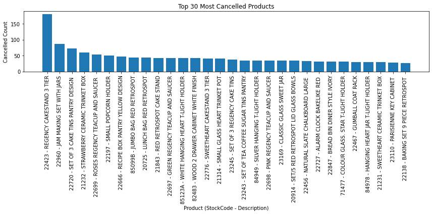

```python
# Assuming df is your DataFrame
# Filter rows where InvoiceNo starts with 'C' (indicating cancellations)
canceled_df = df[df['InvoiceNo'].str.startswith('C')]

# Group by StockCode and Description, then calculate the count of canceled products
cancelled_products = canceled_df.groupby(['StockCode', 'Description']).agg(
    cancelled_count=('StockCode', 'size')
).reset_index()

# Sort by the number of canceled products to get the top 20 most canceled ones
top_30_cancelled_products = cancelled_products.sort_values(by='cancelled_count', ascending=False).head(30)

# Plotting the bar graph for the most canceled products
plt.figure(figsize=(12, 6))
plt.bar(top_30_cancelled_products['StockCode'] + ' - ' + top_30_cancelled_products['Description'],
        top_30_cancelled_products['cancelled_count'], color='tab:blue')

plt.xlabel('Product (StockCode - Description)')
plt.ylabel('Cancelled Count')
plt.title('Top 30 Most Cancelled Products')
plt.xticks(rotation=90)
plt.tight_layout()

# Show the plot
plt.show()
```

[figure not shown]

```python
# Filter only the top 20 most canceled products from canceled_df
top_30_cancelled_data = canceled_df[canceled_df['StockCode'].isin(top_30_cancelled_products['StockCode'])]

# Group by StockCode and Description again, but now calculate the average unit price
avg_price_top_30 = top_30_cancelled_data.groupby(['StockCode', 'Description']).agg(
    avg_unit_price=('UnitPrice', 'mean')
).reset_index()

# Ensure that the products are sorted in the same order as Part 1
avg_price_top_30 = avg_price_top_30.set_index('StockCode').loc[top_30_cancelled_products['StockCode']].reset_index()

# Plotting the bar graph for the average unit price of the top 20 most canceled products
plt.figure(figsize=(12, 6))
plt.bar(avg_price_top_30['StockCode'] + ' - ' + avg_price_top_30['Description'],
        avg_price_top_30['avg_unit_price'], color='tab:red')

plt.xlabel('Product (StockCode - Description)')
plt.ylabel('Average Unit Price')
plt.title('Average Unit Price of Top 20 Most Cancelled Products')
plt.xticks(rotation=90)
plt.tight_layout()

# Show the plot
plt.show()
```

# 3. Feature Engineering

In order to create a comprehensive customer-centric dataset for clustering and recommendation, the following features can be engineered from the available data:

## 3.1 RFM Features

RFM is a method used to analyze customer value and group customers based on their behavior. It stands for:

Recency (R): This measures how recently a customer made a purchase. If the recency value is low, it means the customer bought something recently, showing they are more engaged with the brand.

Frequency (F): This measures how often a customer buys something in a certain period. A higher frequency means the customer buys more often, suggesting they are more loyal or satisfied.

Monetary (M): This measures how much money a customer has spent in a given time. Customers who spend more have a higher monetary value, showing they bring more value to the business.

Using RFM helps understand customer behavior and preferences, which is important for personalizing marketing and creating recommendations.

### 3.1.1 RECENCY

In this step, we look at how recently a customer made a purchase. This helps us understand how engaged each customer is. We are going to define a new feature:

Days Since Last Purchase: This shows how many days have passed since a customer’s last purchase. A small number of days means the customer bought something recently, so they are more engaged with the business. A large number of days means the customer hasn’t bought anything in a while, which could mean less engagement. Knowing this helps businesses create marketing strategies to reach out to customers who haven’t purchased recently, aiming to bring them back and keep them loyal.

```python
# Convert InvoiceDate to datetime type
df['InvoiceDate'] = pd.to_datetime(df['InvoiceDate'])

# Convert InvoiceDate to datetime and extract only the date
df['InvoiceDay'] = df['InvoiceDate'].dt.date

# Find the most recent purchase date for each customer
customer_data = df.groupby('CustomerID')['InvoiceDay'].max().reset_index()

# Find the most recent date in the entire dataset
most_recent_date = df['InvoiceDay'].max()

# Convert InvoiceDay to datetime type before subtraction
customer_data['InvoiceDay'] = pd.to_datetime(customer_data['InvoiceDay'])
most_recent_date = pd.to_datetime(most_recent_date)

# Calculate the number of days since the last purchase for each customer
customer_data['Days_Since_Last_Purchase'] = (most_recent_date - customer_data['InvoiceDay']).dt.days

# Remove the InvoiceDay column
customer_data.drop(columns=['InvoiceDay'], inplace=True)
```

```python
customer_data.head(20)

#We've named the customer-centric dataframe as customer_data, which will eventually contain all the customer-based features we plan to create.
```

|  | CustomerID | Days_Since_Last_Purchase |
| --- | --- | --- |
| 0 | 12346.0 | 325 |
| 1 | 12347.0 | 2 |
| 2 | 12348.0 | 75 |
| 3 | 12349.0 | 18 |
| 4 | 12350.0 | 310 |
| 5 | 12352.0 | 36 |
| 6 | 12353.0 | 204 |
| 7 | 12354.0 | 232 |
| 8 | 12355.0 | 214 |
| 9 | 12356.0 | 22 |
| 10 | 12357.0 | 33 |
| 11 | 12358.0 | 1 |
| 12 | 12359.0 | 7 |
| 13 | 12360.0 | 52 |
| 14 | 12361.0 | 287 |
| 15 | 12362.0 | 3 |
| 16 | 12363.0 | 109 |
| 17 | 12364.0 | 7 |
| 18 | 12365.0 | 291 |
| 19 | 12367.0 | 4 |

### 3.1.2 FREQUENCY

In this step, we are going to create two features that show how often a customer buys from the retailer:

Total Transactions: This counts how many times a customer has made a purchase. It helps us see how often the customer shops with the retailer.

Total Products Purchased: This shows the total number of products a customer has bought, adding up the quantities from all their purchases. It helps us understand how much the customer buys in terms of product volume.

These features will help us group customers based on how frequently they buy, which is important for targeted marketing and making personalized recommendations.

```python
# Calculate the total number of transactions made by each customer
total_transactions = df.groupby('CustomerID')['InvoiceNo'].nunique().reset_index()
total_transactions.rename(columns={'InvoiceNo': 'Total_Transactions'}, inplace=True)

# Calculate the total number of products purchased by each customer
total_products_purchased = df.groupby('CustomerID')['Quantity'].sum().reset_index()
total_products_purchased.rename(columns={'Quantity': 'Total_Products_Purchased'}, inplace=True)

# Merge the new features into the customer_data dataframe
customer_data = pd.merge(customer_data, total_transactions, on='CustomerID')
customer_data = pd.merge(customer_data, total_products_purchased, on='CustomerID')

# Display the first few rows of the customer_data dataframe
customer_data.head(10)
```

|  | CustomerID | Days_Since_Last_Purchase | Total_Transactions | Total_Products_Purchased |
| --- | --- | --- | --- | --- |
| 0 | 12346.0 | 325 | 2 | 0 |
| 1 | 12347.0 | 2 | 7 | 2458 |
| 2 | 12348.0 | 75 | 4 | 2332 |
| 3 | 12349.0 | 18 | 1 | 627 |
| 4 | 12350.0 | 310 | 1 | 196 |
| 5 | 12352.0 | 36 | 8 | 463 |
| 6 | 12353.0 | 204 | 1 | 20 |
| 7 | 12354.0 | 232 | 1 | 530 |
| 8 | 12355.0 | 214 | 1 | 240 |
| 9 | 12356.0 | 22 | 3 | 1573 |

### 3.1.3 MONETARY

In this step, we will create two features that show the monetary side of customer purchases:

Total Spend: This shows the total amount of money each customer has spent. It’s calculated by multiplying the unit price by the quantity for each purchase and then adding up all these amounts. This helps us see how much revenue each customer brings to the business.

Average Transaction Value: This is calculated by dividing the Total Spend by the Total Transactions for each customer. It shows the average amount of money spent in each transaction. This helps us understand how much customers spend on average per purchase, which can be useful for creating targeted marketing and offers.

```python
# Calculate the total spend by each customer
df['Total_Spend'] = df['UnitPrice'] * df['Quantity']
total_spend = df.groupby('CustomerID')['Total_Spend'].sum().reset_index()

# Calculate the average transaction value for each customer
average_transaction_value = total_spend.merge(total_transactions, on='CustomerID')
average_transaction_value['Average_Transaction_Value'] = average_transaction_value['Total_Spend'] / average_transaction_value['Total_Transactions']

# Merge the new features into the customer_data dataframe
customer_data = pd.merge(customer_data, total_spend, on='CustomerID')
customer_data = pd.merge(customer_data, average_transaction_value[['CustomerID', 'Average_Transaction_Value']], on='CustomerID')

# Display the first few rows of the customer_data dataframe
customer_data.head()
```

|  | CustomerID | Days_Since_Last_Purchase | Total_Transactions | Total_Products_Purchased | Total_Spend | Average_Transaction_Value |
| --- | --- | --- | --- | --- | --- | --- |
| 0 | 12346.0 | 325 | 2 | 0 | 0.00 | 0.000000 |
| 1 | 12347.0 | 2 | 7 | 2458 | 4310.00 | 615.714286 |
| 2 | 12348.0 | 75 | 4 | 2332 | 1437.24 | 359.310000 |
| 3 | 12349.0 | 18 | 1 | 627 | 1442.70 | 1442.700000 |
| 4 | 12350.0 | 310 | 1 | 196 | 294.40 | 294.400000 |

## 3.2 PRODUCT DIVERSITY

In this step, we’re going to look at how diverse customers’ product purchases are. This helps in making personalized marketing and product recommendations.

We are defining a new feature:

Unique Products Purchased: This shows how many different products a customer has bought. If the number is high, it means the customer likes a wide variety of products. If the number is low, the customer prefers only a few specific products. Knowing this helps us group customers based on how diverse their purchases are, which is important for tailoring product recommendations.

```python
# Calculate the number of unique products purchased by each customer
unique_products_purchased = df.groupby('CustomerID')['StockCode'].nunique().reset_index()
unique_products_purchased.rename(columns={'StockCode': 'Unique_Products_Purchased'}, inplace=True)

# Merge the new feature into the customer_data dataframe
customer_data = pd.merge(customer_data, unique_products_purchased, on='CustomerID')

# Display the first few rows of the customer_data dataframe
customer_data.head()
```

|  | CustomerID | Days_Since_Last_Purchase | Total_Transactions | Total_Products_Purchased | Total_Spend | Average_Transaction_Value | Unique_Products_Purchased |
| --- | --- | --- | --- | --- | --- | --- | --- |
| 0 | 12346.0 | 325 | 2 | 0 | 0.00 | 0.000000 | 1 |
| 1 | 12347.0 | 2 | 7 | 2458 | 4310.00 | 615.714286 | 103 |
| 2 | 12348.0 | 75 | 4 | 2332 | 1437.24 | 359.310000 | 21 |
| 3 | 12349.0 | 18 | 1 | 627 | 1442.70 | 1442.700000 | 71 |
| 4 | 12350.0 | 310 | 1 | 196 | 294.40 | 294.400000 | 16 |

## 3.3 BEHAVIORAL FEATURES

In this step, we’re going to look at how customers shop to better understand their habits. This will help us personalize their shopping experience. Here are the features I plan to add:

Average Days Between Purchases: This shows how many days, on average, a customer waits before buying something again. Knowing this helps us predict when a customer might buy next, which is useful for targeting marketing and promotions.

Favorite Shopping Day: This tells us which day of the week a customer shops the most. This information can help us target marketing and promotions on the days customers are most likely to shop.

Favorite Shopping Hour: This indicates the time of day when a customer shops the most. Knowing this helps us time our marketing campaigns and promotions to match when customers are most active.

By adding these features, we can get a better picture of our customers and improve how we group them, leading to more effective marketing and recommendations.

```python
# Extract day of week and hour from InvoiceDate
df['Day_Of_Week'] = df['InvoiceDate'].dt.dayofweek
df['Hour'] = df['InvoiceDate'].dt.hour

# Calculate the average number of days between consecutive purchases
days_between_purchases = df.groupby('CustomerID')['InvoiceDay'].apply(lambda x: (x.diff().dropna()).apply(lambda y: y.days))
average_days_between_purchases = days_between_purchases.groupby('CustomerID').mean().reset_index()
average_days_between_purchases.rename(columns={'InvoiceDay': 'Average_Days_Between_Purchases'}, inplace=True)

# Find the favorite shopping day of the week
favorite_shopping_day = df.groupby(['CustomerID', 'Day_Of_Week']).size().reset_index(name='Count')
favorite_shopping_day = favorite_shopping_day.loc[favorite_shopping_day.groupby('CustomerID')['Count'].idxmax()][['CustomerID', 'Day_Of_Week']]

# Find the favorite shopping hour of the day
favorite_shopping_hour = df.groupby(['CustomerID', 'Hour']).size().reset_index(name='Count')
favorite_shopping_hour = favorite_shopping_hour.loc[favorite_shopping_hour.groupby('CustomerID')['Count'].idxmax()][['CustomerID', 'Hour']]

# Merge the new features into the customer_data dataframe
customer_data = pd.merge(customer_data, average_days_between_purchases, on='CustomerID')
customer_data = pd.merge(customer_data, favorite_shopping_day, on='CustomerID')
customer_data = pd.merge(customer_data, favorite_shopping_hour, on='CustomerID')

# Display the first few rows of the customer_data dataframe
customer_data.head()
```

|  | CustomerID | Days_Since_Last_Purchase | Total_Transactions | Total_Products_Purchased | Total_Spend | Average_Transaction_Value | Unique_Products_Purchased | Average_Days_Between_Purchases | Day_Of_Week | Hour |
| --- | --- | --- | --- | --- | --- | --- | --- | --- | --- | --- |
| 0 | 12346.0 | 325 | 2 | 0 | 0.00 | 0.000000 | 1 | 0.000000 | 1 | 0 |
| 1 | 12347.0 | 2 | 7 | 2458 | 4310.00 | 615.714286 | 103 | 2.016575 | 1 | 0 |
| 2 | 12348.0 | 75 | 4 | 2332 | 1437.24 | 359.310000 | 21 | 10.884615 | 3 | 0 |
| 3 | 12349.0 | 18 | 1 | 627 | 1442.70 | 1442.700000 | 71 | 0.000000 | 0 | 0 |
| 4 | 12350.0 | 310 | 1 | 196 | 294.40 | 294.400000 | 16 | 0.000000 | 2 | 0 |

## 3.4 GEOGRAPHIC FEATURES

In this step, we’ll add a geographic feature to reflect where customers are located. Knowing where customers are based is important for several reasons:

Country: This shows which country each customer is from. Knowing this helps us see different buying patterns and preferences in various regions. This information is useful for personalizing marketing, planning inventory, and improving shipping and delivery, especially for an online store.

```python
df['Country'].value_counts(normalize=True).head()
```

```
Country
United Kingdom    0.915463
Germany           0.017059
France            0.015374
EIRE              0.015166
Spain             0.004636
Name: proportion, dtype: float64
```

Since 91% of transactions come from the United Kingdom, we might add a simple feature to show if a transaction is from the UK or not.

First, we will group the data by CustomerID and Country to count how many transactions each customer has in each country.  
Next, we will figure out the main country for each customer by finding the country where they have the most transactions.  
Then, we will add a column to show if each customer is from the UK or not.  
Finally, we will add this new information to our customer_data dataframe so we can use it in our analysis.

```python
# Group by CustomerID and Country to get the number of transactions per country for each customer
customer_country = df.groupby(['CustomerID', 'Country']).size().reset_index(name='Number_of_Transactions')

# Get the country with the maximum number of transactions for each customer (in case a customer has transactions from multiple countries)
customer_main_country = customer_country.sort_values('Number_of_Transactions', ascending=False).drop_duplicates('CustomerID')

# Create a binary column indicating whether the customer is from the UK or not
customer_main_country['Is_UK'] = customer_main_country['Country'].apply(lambda x: 1 if x == 'United Kingdom' else 0)

# Merge this data with our customer_data dataframe
customer_data = pd.merge(customer_data, customer_main_country[['CustomerID', 'Is_UK']], on='CustomerID', how='left')

# Display the first few rows of the customer_data dataframe
customer_data.head()
```

|  | CustomerID | Days_Since_Last_Purchase | Total_Transactions | Total_Products_Purchased | Total_Spend | Average_Transaction_Value | Unique_Products_Purchased | Average_Days_Between_Purchases | Day_Of_Week | Hour | Is_UK |
| --- | --- | --- | --- | --- | --- | --- | --- | --- | --- | --- | --- |
| 0 | 12346.0 | 325 | 2 | 0 | 0.00 | 0.000000 | 1 | 0.000000 | 1 | 0 | 1 |
| 1 | 12347.0 | 2 | 7 | 2458 | 4310.00 | 615.714286 | 103 | 2.016575 | 1 | 0 | 0 |
| 2 | 12348.0 | 75 | 4 | 2332 | 1437.24 | 359.310000 | 21 | 10.884615 | 3 | 0 | 0 |
| 3 | 12349.0 | 18 | 1 | 627 | 1442.70 | 1442.700000 | 71 | 0.000000 | 0 | 0 | 0 |
| 4 | 12350.0 | 310 | 1 | 196 | 294.40 | 294.400000 | 16 | 0.000000 | 2 | 0 | 0 |

```python
# Display feature distribution
customer_data['Is_UK'].value_counts()
```

```
Is_UK
1    3867
0     416
Name: count, dtype: int64
```

## 3.5 CANCELLATION INSIGHTS

Here we are going to look more closely at customer cancellations to improve our customer segmentation. Here’s what we will do:  
Cancellation Frequency: This shows how many transactions each customer has canceled. Knowing this helps us spot customers who cancel often, which could mean they’re unhappy or have other issues. We can then develop strategies to reduce cancellations and improve customer satisfaction.  
Cancellation Rate: This shows the percentage of a customer’s transactions that were canceled. It helps us see how often customers cancel compared to all their purchases. A high rate might suggest problems with those customers. By finding these segments, we can create targeted strategies to improve their experience and lower cancellation rates.  
Adding these cancellation insights will give us a better understanding of customer behavior and help us create more effective customer segments.

```python
# Calculate the total number of transactions made by each customer
total_transactions = df.groupby('CustomerID')['InvoiceNo'].nunique().reset_index()

# Calculate the number of cancelled transactions for each customer
cancelled_transactions = df[df['Transaction_Status'] == 'Cancelled']
cancellation_frequency = cancelled_transactions.groupby('CustomerID')['InvoiceNo'].nunique().reset_index()
cancellation_frequency.rename(columns={'InvoiceNo': 'Cancellation_Frequency'}, inplace=True)

# Merge the Cancellation Frequency data into the customer_data dataframe
customer_data = pd.merge(customer_data, cancellation_frequency, on='CustomerID', how='left')

# Replace NaN values with 0 (for customers who have not cancelled any transaction)
customer_data['Cancellation_Frequency'].fillna(0, inplace=True)

# Calculate the Cancellation Rate
customer_data['Cancellation_Rate'] = customer_data['Cancellation_Frequency'] / total_transactions['InvoiceNo']

# Display the first few rows of the customer_data dataframe
customer_data.head()
```

|  | CustomerID | Days_Since_Last_Purchase | Total_Transactions | Total_Products_Purchased | Total_Spend | Average_Transaction_Value | Unique_Products_Purchased | Average_Days_Between_Purchases | Day_Of_Week | Hour | Is_UK | Cancellation_Frequency | Cancellation_Rate |
| --- | --- | --- | --- | --- | --- | --- | --- | --- | --- | --- | --- | --- | --- |
| 0 | 12346.0 | 325 | 2 | 0 | 0.00 | 0.000000 | 1 | 0.000000 | 1 | 0 | 1 | 1.0 | 0.5 |
| 1 | 12347.0 | 2 | 7 | 2458 | 4310.00 | 615.714286 | 103 | 2.016575 | 1 | 0 | 0 | 0.0 | 0.0 |
| 2 | 12348.0 | 75 | 4 | 2332 | 1437.24 | 359.310000 | 21 | 10.884615 | 3 | 0 | 0 | 0.0 | 0.0 |
| 3 | 12349.0 | 18 | 1 | 627 | 1442.70 | 1442.700000 | 71 | 0.000000 | 0 | 0 | 0 | 0.0 | 0.0 |
| 4 | 12350.0 | 310 | 1 | 196 | 294.40 | 294.400000 | 16 | 0.000000 | 2 | 0 | 0 | 0.0 | 0.0 |

## 3.6 TRENDS AND SEASONALITY

In this step, we are going to explore how customers' spending habits change over time. This will help us make better marketing strategies and improve customer satisfaction. Here is what we plan to add:  
Monthly Spending Mean: This shows the average amount a customer spends each month. A higher average means they spend more, possibly on premium items. A lower average suggests they’re more budget-conscious.  
Monthly Spending Std: This shows how much a customer’s spending changes from month to month. A high value means their spending is very variable, with big purchases sometimes. A low value means their spending is more consistent. Knowing this helps us create promotions or discounts when customers are likely to spend more.  
Spending Trend: This shows if a customer’s spending is going up or down over time. A positive trend means they’re spending more, which could indicate growing loyalty. A negative trend means they’re spending less, which might signal they’re losing interest. A stable trend means their spending hasn’t changed much. Understanding these trends helps us develop strategies to either encourage more spending or re-engage customers.  
Adding these insights will help us create better customer groups and more targeted marketing strategies.

```python
# Extract month and year from InvoiceDate
df['Year'] = df['InvoiceDate'].dt.year
df['Month'] = df['InvoiceDate'].dt.month

# Calculate monthly spending for each customer
monthly_spending = df.groupby(['CustomerID', 'Year', 'Month'])['Total_Spend'].sum().reset_index()

# Calculate Seasonal Buying Patterns: We are using monthly frequency as a proxy for seasonal buying patterns
seasonal_buying_patterns = monthly_spending.groupby('CustomerID')['Total_Spend'].agg(['mean', 'std']).reset_index()
seasonal_buying_patterns.rename(columns={'mean': 'Monthly_Spending_Mean', 'std': 'Monthly_Spending_Std'}, inplace=True)

# Replace NaN values in Monthly_Spending_Std with 0, implying no variability for customers with single transaction month
seasonal_buying_patterns['Monthly_Spending_Std'].fillna(0, inplace=True)

# Calculate Trends in Spending
# We are using the slope of the linear trend line fitted to the customer's spending over time as an indicator of spending trends
def calculate_trend(spend_data):
    # If there are more than one data points, we calculate the trend using linear regression
    if len(spend_data) > 1:
        x = np.arange(len(spend_data))
        slope, _, _, _, _ = linregress(x, spend_data)
        return slope
    # If there is only one data point, no trend can be calculated, hence we return 0
    else:
        return 0

# Apply the calculate_trend function to find the spending trend for each customer
spending_trends = monthly_spending.groupby('CustomerID')['Total_Spend'].apply(calculate_trend).reset_index()
spending_trends.rename(columns={'Total_Spend': 'Spending_Trend'}, inplace=True)

# Merge the new features into the customer_data dataframe
customer_data = pd.merge(customer_data, seasonal_buying_patterns, on='CustomerID')
customer_data = pd.merge(customer_data, spending_trends, on='CustomerID')

# Display the first few rows of the customer_data dataframe
customer_data.head(10)
```

|  | CustomerID | Days_Since_Last_Purchase | Total_Transactions | Total_Products_Purchased | Total_Spend | Average_Transaction_Value | Unique_Products_Purchased | Average_Days_Between_Purchases | Day_Of_Week | Hour | Is_UK | Cancellation_Frequency | Cancellation_Rate | Monthly_Spending_Mean | Monthly_Spending_Std | Spending_Trend |
| --- | --- | --- | --- | --- | --- | --- | --- | --- | --- | --- | --- | --- | --- | --- | --- | --- |
| 0 | 12346.0 | 325 | 2 | 0 | 0.00 | 0.000000 | 1 | 0.000000 | 1 | 0 | 1 | 1.0 | 0.500 | 0.000000 | 0.000000 | 0.000000 |
| 1 | 12347.0 | 2 | 7 | 2458 | 4310.00 | 615.714286 | 103 | 2.016575 | 1 | 0 | 0 | 0.0 | 0.000 | 615.714286 | 341.070789 | 4.486071 |
| 2 | 12348.0 | 75 | 4 | 2332 | 1437.24 | 359.310000 | 21 | 10.884615 | 3 | 0 | 0 | 0.0 | 0.000 | 359.310000 | 203.875689 | -100.884000 |
| 3 | 12349.0 | 18 | 1 | 627 | 1442.70 | 1442.700000 | 71 | 0.000000 | 0 | 0 | 0 | 0.0 | 0.000 | 1442.700000 | 0.000000 | 0.000000 |
| 4 | 12350.0 | 310 | 1 | 196 | 294.40 | 294.400000 | 16 | 0.000000 | 2 | 0 | 0 | 0.0 | 0.000 | 294.400000 | 0.000000 | 0.000000 |
| 5 | 12352.0 | 36 | 8 | 463 | 1265.41 | 158.176250 | 57 | 3.132530 | 1 | 0 | 0 | 1.0 | 0.125 | 316.352500 | 134.700629 | 9.351000 |
| 6 | 12353.0 | 204 | 1 | 20 | 89.00 | 89.000000 | 4 | 0.000000 | 3 | 0 | 0 | 0.0 | 0.000 | 89.000000 | 0.000000 | 0.000000 |
| 7 | 12354.0 | 232 | 1 | 530 | 1079.40 | 1079.400000 | 58 | 0.000000 | 3 | 0 | 0 | 0.0 | 0.000 | 1079.400000 | 0.000000 | 0.000000 |
| 8 | 12355.0 | 214 | 1 | 240 | 459.40 | 459.400000 | 13 | 0.000000 | 0 | 0 | 0 | 0.0 | 0.000 | 459.400000 | 0.000000 | 0.000000 |
| 9 | 12356.0 | 22 | 3 | 1573 | 2487.43 | 829.143333 | 52 | 5.315789 | 1 | 0 | 0 | 0.0 | 0.000 | 829.143333 | 991.462585 | -944.635000 |

```python
# Changing the data type of 'CustomerID' to string as it is a unique identifier and not used in mathematical operations
customer_data['CustomerID'] = customer_data['CustomerID'].astype(str)

# Convert data types of columns to optimal types
customer_data = customer_data.convert_dtypes()
```

```python
customer_data.head(10)
```

|  | CustomerID | Days_Since_Last_Purchase | Total_Transactions | Total_Products_Purchased | Total_Spend | Average_Transaction_Value | Unique_Products_Purchased | Average_Days_Between_Purchases | Day_Of_Week | Hour | Is_UK | Cancellation_Frequency | Cancellation_Rate | Monthly_Spending_Mean | Monthly_Spending_Std | Spending_Trend |
| --- | --- | --- | --- | --- | --- | --- | --- | --- | --- | --- | --- | --- | --- | --- | --- | --- |
| 0 | 12346.0 | 325 | 2 | 0 | 0.0 | 0.0 | 1 | 0.0 | 1 | 0 | 1 | 1 | 0.5 | 0.0 | 0.0 | 0.0 |
| 1 | 12347.0 | 2 | 7 | 2458 | 4310.0 | 615.714286 | 103 | 2.016575 | 1 | 0 | 0 | 0 | 0.0 | 615.714286 | 341.070789 | 4.486071 |
| 2 | 12348.0 | 75 | 4 | 2332 | 1437.24 | 359.31 | 21 | 10.884615 | 3 | 0 | 0 | 0 | 0.0 | 359.31 | 203.875689 | -100.884 |
| 3 | 12349.0 | 18 | 1 | 627 | 1442.7 | 1442.7 | 71 | 0.0 | 0 | 0 | 0 | 0 | 0.0 | 1442.7 | 0.0 | 0.0 |
| 4 | 12350.0 | 310 | 1 | 196 | 294.4 | 294.4 | 16 | 0.0 | 2 | 0 | 0 | 0 | 0.0 | 294.4 | 0.0 | 0.0 |
| 5 | 12352.0 | 36 | 8 | 463 | 1265.41 | 158.17625 | 57 | 3.13253 | 1 | 0 | 0 | 1 | 0.125 | 316.3525 | 134.700629 | 9.351 |
| 6 | 12353.0 | 204 | 1 | 20 | 89.0 | 89.0 | 4 | 0.0 | 3 | 0 | 0 | 0 | 0.0 | 89.0 | 0.0 | 0.0 |
| 7 | 12354.0 | 232 | 1 | 530 | 1079.4 | 1079.4 | 58 | 0.0 | 3 | 0 | 0 | 0 | 0.0 | 1079.4 | 0.0 | 0.0 |
| 8 | 12355.0 | 214 | 1 | 240 | 459.4 | 459.4 | 13 | 0.0 | 0 | 0 | 0 | 0 | 0.0 | 459.4 | 0.0 | 0.0 |
| 9 | 12356.0 | 22 | 3 | 1573 | 2487.43 | 829.143333 | 52 | 5.315789 | 1 | 0 | 0 | 0 | 0.0 | 829.143333 | 991.462585 | -944.635 |

```python
customer_data.info()
```

```
<class 'pandas.core.frame.DataFrame'>
RangeIndex: 4283 entries, 0 to 4282
Data columns (total 16 columns):
 #   Column                          Non-Null Count  Dtype
---  ------                          --------------  -----
 0   CustomerID                      4283 non-null   string
 1   Days_Since_Last_Purchase        4283 non-null   Int64
 2   Total_Transactions              4283 non-null   Int64
 3   Total_Products_Purchased        4283 non-null   Int64
 4   Total_Spend                     4283 non-null   Float64
 5   Average_Transaction_Value       4283 non-null   Float64
 6   Unique_Products_Purchased       4283 non-null   Int64
 7   Average_Days_Between_Purchases  4283 non-null   Float64
 8   Day_Of_Week                     4283 non-null   Int32
 9   Hour                            4283 non-null   Int32
 10  Is_UK                           4283 non-null   Int64
 11  Cancellation_Frequency          4283 non-null   Int64
 12  Cancellation_Rate               4283 non-null   Float64
 13  Monthly_Spending_Mean           4283 non-null   Float64
 14  Monthly_Spending_Std            4283 non-null   Float64
 15  Spending_Trend                  4283 non-null   Float64
dtypes: Float64(7), Int32(2), Int64(6), string(1)
memory usage: 564.8 KB
```

**Customer Dataset Description:**

Setting up our dataset with detailed features that help us understand our customers' buying habits and preferences.

Next, we need to:

Analyze the Data: Look for patterns and trends in the data.  
Check for Outliers: Identify and handle any unusual data points.

These steps will help us build strong customer segments and create a personalized recommendation system.

# 4. OUTLIER DETECTION AND TREATMENT

In this part, we’ll find and handle outliers in our dataset. Outliers are unusual data points that can mess up our analysis, especially with k-means clustering, where they can affect where clusters are formed.

Since our data has many dimensions, we’ll use a special algorithm called Isolation Forest to spot outliers. This method is good for multi-dimensional data and is efficient. It works by randomly choosing features and split points to isolate data points.

Let's use this method to identify and deal with outliers.

```python
# Initializing the IsolationForest model with a contamination parameter of 0.05 (This parameter is on the basis of domain standards, in retail for fraud detection it is generaly from 1%-2% while in inventory it is 3%-5% and in customer segmentation it is 2%-5%.)
model = IsolationForest(contamination=0.05, random_state=0)

# Fitting the model on our dataset (converting DataFrame to NumPy to avoid warning)
customer_data['Outlier_Scores'] = model.fit_predict(customer_data.iloc[:, 1:].to_numpy())

# Creating a new column to identify outliers (1 for inliers and -1 for outliers)
customer_data['Is_Outlier'] = [1 if x == -1 else 0 for x in customer_data['Outlier_Scores']]

# Display the first few rows of the customer_data dataframe
customer_data.head()
```

|  | CustomerID | Days_Since_Last_Purchase | Total_Transactions | Total_Products_Purchased | Total_Spend | Average_Transaction_Value | Unique_Products_Purchased | Average_Days_Between_Purchases | Day_Of_Week | Hour | Is_UK | Cancellation_Frequency | Cancellation_Rate | Monthly_Spending_Mean | Monthly_Spending_Std | Spending_Trend | Outlier_Scores | Is_Outlier |
| --- | --- | --- | --- | --- | --- | --- | --- | --- | --- | --- | --- | --- | --- | --- | --- | --- | --- | --- |
| 0 | 12346.0 | 325 | 2 | 0 | 0.0 | 0.0 | 1 | 0.0 | 1 | 0 | 1 | 1 | 0.5 | 0.0 | 0.0 | 0.0 | 1 | 0 |
| 1 | 12347.0 | 2 | 7 | 2458 | 4310.0 | 615.714286 | 103 | 2.016575 | 1 | 0 | 0 | 0 | 0.0 | 615.714286 | 341.070789 | 4.486071 | 1 | 0 |
| 2 | 12348.0 | 75 | 4 | 2332 | 1437.24 | 359.31 | 21 | 10.884615 | 3 | 0 | 0 | 0 | 0.0 | 359.31 | 203.875689 | -100.884 | 1 | 0 |
| 3 | 12349.0 | 18 | 1 | 627 | 1442.7 | 1442.7 | 71 | 0.0 | 0 | 0 | 0 | 0 | 0.0 | 1442.7 | 0.0 | 0.0 | 1 | 0 |
| 4 | 12350.0 | 310 | 1 | 196 | 294.4 | 294.4 | 16 | 0.0 | 2 | 0 | 0 | 0 | 0.0 | 294.4 | 0.0 | 0.0 | 1 | 0 |

Here's how we'll handle the country information for our customers:

Group Data: First, we'll group the data by each customer and their country to count how many transactions each customer made in each country.

Find Main Country: Then, we'll determine which country has the most transactions for each customer and consider that as their main country.

Create UK Indicator: Next, we’ll add a new column to mark if a customer is from the UK or not.

Update Data: Finally, we’ll add this new information to our existing customer data to use in our analysis.

```python
# Group by CustomerID and Country to get the number of transactions per country for each customer
customer_country = df.groupby(['CustomerID', 'Country']).size().reset_index(name='Number_of_Transactions')

# Get the country with the maximum number of transactions for each customer (in case a customer has transactions from multiple countries)
customer_main_country = customer_country.sort_values('Number_of_Transactions', ascending=False).drop_duplicates('CustomerID')

# Create a binary column indicating whether the customer is from the UK or not
customer_main_country['Is_UK'] = customer_main_country['Country'].apply(lambda x: 1 if x == 'United Kingdom' else 0)

# Merge this data with our customer_data dataframe
customer_data = pd.merge(customer_data, customer_main_country[['CustomerID', 'Is_UK']], on='CustomerID', how='left')

# Display the first few rows of the customer_data dataframe
customer_data.head()
```

|  | CustomerID | Days_Since_Last_Purchase | Total_Transactions | Total_Products_Purchased | Total_Spend | Average_Transaction_Value | Unique_Products_Purchased | Average_Days_Between_Purchases | Day_Of_Week | Hour | Is_UK_x | Cancellation_Frequency | Cancellation_Rate | Monthly_Spending_Mean | Monthly_Spending_Std | Spending_Trend | Outlier_Scores | Is_Outlier | Is_UK_y |
| --- | --- | --- | --- | --- | --- | --- | --- | --- | --- | --- | --- | --- | --- | --- | --- | --- | --- | --- | --- |
| 0 | 12346.0 | 325 | 2 | 0 | 0.0 | 0.0 | 1 | 0.0 | 1 | 0 | 1 | 1 | 0.5 | 0.0 | 0.0 | 0.0 | 1 | 0 | 1 |
| 1 | 12347.0 | 2 | 7 | 2458 | 4310.0 | 615.714286 | 103 | 2.016575 | 1 | 0 | 0 | 0 | 0.0 | 615.714286 | 341.070789 | 4.486071 | 1 | 0 | 0 |
| 2 | 12348.0 | 75 | 4 | 2332 | 1437.24 | 359.31 | 21 | 10.884615 | 3 | 0 | 0 | 0 | 0.0 | 359.31 | 203.875689 | -100.884 | 1 | 0 | 0 |
| 3 | 12349.0 | 18 | 1 | 627 | 1442.7 | 1442.7 | 71 | 0.0 | 0 | 0 | 0 | 0 | 0.0 | 1442.7 | 0.0 | 0.0 | 1 | 0 | 0 |
| 4 | 12350.0 | 310 | 1 | 196 | 294.4 | 294.4 | 16 | 0.0 | 2 | 0 | 0 | 0 | 0.0 | 294.4 | 0.0 | 0.0 | 1 | 0 | 0 |

Next, we’ll look at these scores to see how they are spread out and count how many records are considered normal (inliers) and how many are outliers. This will help us understand the results better.

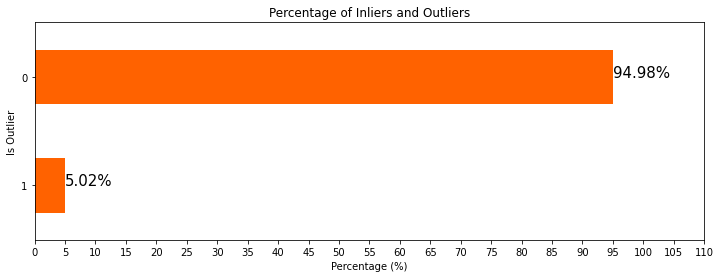

```python
# Calculate the percentage of inliers and outliers
outlier_percentage = customer_data['Is_Outlier'].value_counts(normalize=True) * 100

# Plotting the percentage of inliers and outliers
plt.figure(figsize=(12, 4))
outlier_percentage.plot(kind='barh', color='#ff6200')

# Adding the percentage labels on the bars
for index, value in enumerate(outlier_percentage):
    plt.text(value, index, f'{value:.2f}%', fontsize=15)

plt.title('Percentage of Inliers and Outliers')
plt.xticks(ticks=np.arange(0, 115, 5))
plt.xlabel('Percentage (%)')
plt.ylabel('Is Outlier')
plt.gca().invert_yaxis()
plt.show()
```

From the plot, we can see that about 5% of our customers are marked as outliers. This is a good amount—not so high that we lose too much data, and not so low that we keep too much noisy data. This means our Isolation Forest algorithm did a good job finding a balanced number of outliers, which will help us improve our customer segmentation.

**Strategy:**

Since outliers can mess up our clustering results, we'll handle them carefully. Here’s what we’ll do:

Save Outliers Separately: We'll put the outliers into a separate file to look at them later (this step is optional). Remove Outliers: We’ll take these outliers out of our main dataset so they don't mess up our clustering. Clean Up: We’ll remove the columns we used to find outliers, like Outlier_Scores and Is_Outlier. Now, let's go ahead and do these steps.

```python
# Separate the outliers for analysis
outliers_data = customer_data[customer_data['Is_Outlier'] == 1]

# Remove the outliers from the main dataset
customer_data_cleaned = customer_data[customer_data['Is_Outlier'] == 0]

# Drop the 'Outlier_Scores' and 'Is_Outlier' columns
customer_data_cleaned = customer_data_cleaned.drop(columns=['Outlier_Scores', 'Is_Outlier'])

# Reset the index of the cleaned data
customer_data_cleaned.reset_index(drop=True, inplace=True)
```

We’ve taken care of the outliers by separating them out and cleaning up our main dataset. The cleaned data is now ready for the next steps, which involve scaling the features and using clustering algorithms to find different customer groups. (Before which we must perform variable analysis to understand the different features and their correlation with each other).

```python
# Getting the number of rows in the cleaned customer dataset
customer_data_cleaned.shape[0]
```

```
4068
```

```python
customer_data_cleaned
```

|  | CustomerID | Days_Since_Last_Purchase | Total_Transactions | Total_Products_Purchased | Total_Spend | Average_Transaction_Value | Unique_Products_Purchased | Average_Days_Between_Purchases | Day_Of_Week | Hour | Is_UK_x | Cancellation_Frequency | Cancellation_Rate | Monthly_Spending_Mean | Monthly_Spending_Std | Spending_Trend | Is_UK_y |
| --- | --- | --- | --- | --- | --- | --- | --- | --- | --- | --- | --- | --- | --- | --- | --- | --- | --- |
| 0 | 12346.0 | 325 | 2 | 0 | 0.0 | 0.0 | 1 | 0.0 | 1 | 0 | 1 | 1 | 0.5 | 0.0 | 0.0 | 0.0 | 1 |
| 1 | 12347.0 | 2 | 7 | 2458 | 4310.0 | 615.714286 | 103 | 2.016575 | 1 | 0 | 0 | 0 | 0.0 | 615.714286 | 341.070789 | 4.486071 | 0 |
| 2 | 12348.0 | 75 | 4 | 2332 | 1437.24 | 359.31 | 21 | 10.884615 | 3 | 0 | 0 | 0 | 0.0 | 359.31 | 203.875689 | -100.884 | 0 |
| 3 | 12349.0 | 18 | 1 | 627 | 1442.7 | 1442.7 | 71 | 0.0 | 0 | 0 | 0 | 0 | 0.0 | 1442.7 | 0.0 | 0.0 | 0 |
| 4 | 12350.0 | 310 | 1 | 196 | 294.4 | 294.4 | 16 | 0.0 | 2 | 0 | 0 | 0 | 0.0 | 294.4 | 0.0 | 0.0 | 0 |
| ... | ... | ... | ... | ... | ... | ... | ... | ... | ... | ... | ... | ... | ... | ... | ... | ... | ... |
| 4063 | 18280.0 | 277 | 1 | 45 | 180.6 | 180.6 | 10 | 0.0 | 0 | 0 | 1 | 0 | 0.0 | 180.6 | 0.0 | 0.0 | 1 |
| 4064 | 18281.0 | 180 | 1 | 44 | 64.32 | 64.32 | 6 | 0.0 | 6 | 0 | 1 | 0 | 0.0 | 64.32 | 0.0 | 0.0 | 1 |
| 4065 | 18282.0 | 7 | 3 | 98 | 176.6 | 58.866667 | 12 | 9.916667 | 4 | 0 | 1 | 1 | 0.5 | 88.3 | 14.792674 | -20.92 | 1 |
| 4066 | 18283.0 | 3 | 16 | 1312 | 1956.59 | 122.286875 | 259 | 0.481268 | 3 | 0 | 1 | 0 | 0.0 | 195.659 | 156.83062 | 20.20697 | 1 |
| 4067 | 18287.0 | 42 | 3 | 1586 | 1837.28 | 612.426667 | 59 | 2.304348 | 2 | 0 | 1 | 0 | 0.0 | 918.64 | 216.883792 | 306.72 | 1 |

4068 rows × 17 columns

# 5. CALCULATING CUSTOMER LIFETIME VALUE (CLTV)

```python
# Calculate Purchase Frequency
customer_data_cleaned['Purchase_Frequency'] = customer_data_cleaned['Total_Transactions'] / (customer_data_cleaned['Days_Since_Last_Purchase'] + customer_data_cleaned['Average_Days_Between_Purchases'])

# Approximate Customer Lifespan as the maximum observed period
customer_data_cleaned['Customer_Lifespan'] = customer_data_cleaned['Days_Since_Last_Purchase'] + (customer_data_cleaned['Average_Days_Between_Purchases'] * customer_data_cleaned['Total_Transactions'])

# Calculate CLTV
customer_data_cleaned['CLTV'] = customer_data_cleaned['Average_Transaction_Value'] * customer_data_cleaned['Purchase_Frequency'] * customer_data_cleaned['Customer_Lifespan']
```

```python
customer_data_cleaned
```

|  | CustomerID | Days_Since_Last_Purchase | Total_Transactions | Total_Products_Purchased | Total_Spend | Average_Transaction_Value | Unique_Products_Purchased | Average_Days_Between_Purchases | Day_Of_Week | Hour | Is_UK_x | Cancellation_Frequency | Cancellation_Rate | Monthly_Spending_Mean | Monthly_Spending_Std | Spending_Trend | Is_UK_y | Purchase_Frequency | Customer_Lifespan | CLTV |
| --- | --- | --- | --- | --- | --- | --- | --- | --- | --- | --- | --- | --- | --- | --- | --- | --- | --- | --- | --- | --- |
| 0 | 12346.0 | 325 | 2 | 0 | 0.0 | 0.0 | 1 | 0.0 | 1 | 0 | 1 | 1 | 0.5 | 0.0 | 0.0 | 0.0 | 1 | 0.006154 | 325.0 | 0.0 |
| 1 | 12347.0 | 2 | 7 | 2458 | 4310.0 | 615.714286 | 103 | 2.016575 | 1 | 0 | 0 | 0 | 0.0 | 615.714286 | 341.070789 | 4.486071 | 0 | 1.742779 | 16.116022 | 17293.356259 |
| 2 | 12348.0 | 75 | 4 | 2332 | 1437.24 | 359.31 | 21 | 10.884615 | 3 | 0 | 0 | 0 | 0.0 | 359.31 | 203.875689 | -100.884 | 0 | 0.046574 | 118.538462 | 1983.687273 |
| 3 | 12349.0 | 18 | 1 | 627 | 1442.7 | 1442.7 | 71 | 0.0 | 0 | 0 | 0 | 0 | 0.0 | 1442.7 | 0.0 | 0.0 | 0 | 0.055556 | 18.0 | 1442.7 |
| 4 | 12350.0 | 310 | 1 | 196 | 294.4 | 294.4 | 16 | 0.0 | 2 | 0 | 0 | 0 | 0.0 | 294.4 | 0.0 | 0.0 | 0 | 0.003226 | 310.0 | 294.4 |
| ... | ... | ... | ... | ... | ... | ... | ... | ... | ... | ... | ... | ... | ... | ... | ... | ... | ... | ... | ... | ... |
| 4063 | 18280.0 | 277 | 1 | 45 | 180.6 | 180.6 | 10 | 0.0 | 0 | 0 | 1 | 0 | 0.0 | 180.6 | 0.0 | 0.0 | 1 | 0.00361 | 277.0 | 180.6 |
| 4064 | 18281.0 | 180 | 1 | 44 | 64.32 | 64.32 | 6 | 0.0 | 6 | 0 | 1 | 0 | 0.0 | 64.32 | 0.0 | 0.0 | 1 | 0.005556 | 180.0 | 64.32 |
| 4065 | 18282.0 | 7 | 3 | 98 | 176.6 | 58.866667 | 12 | 9.916667 | 4 | 0 | 1 | 1 | 0.5 | 88.3 | 14.792674 | -20.92 | 1 | 0.17734 | 36.75 | 383.648276 |
| 4066 | 18283.0 | 3 | 16 | 1312 | 1956.59 | 122.286875 | 259 | 0.481268 | 3 | 0 | 1 | 0 | 0.0 | 195.659 | 156.83062 | 20.20697 | 1 | 4.596026 | 10.700288 | 6013.92274 |
| 4067 | 18287.0 | 42 | 3 | 1586 | 1837.28 | 612.426667 | 59 | 2.304348 | 2 | 0 | 1 | 0 | 0.0 | 918.64 | 216.883792 | 306.72 | 1 | 0.067713 | 48.913043 | 2028.400393 |

4068 rows × 20 columns

# 6. VARIABLE ANALYSIS

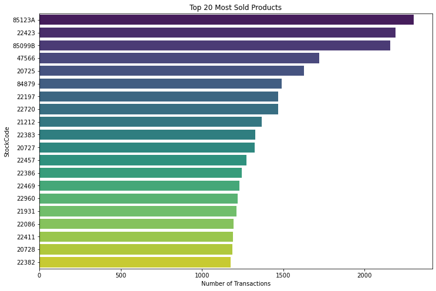

```python
#Finding top 20 most sold products
plt.figure(figsize=(12, 8))
top_products = df['StockCode'].value_counts().head(20)
sns.barplot(x=top_products.values, y=top_products.index, palette='viridis')
plt.title('Top 20 Most Sold Products')
plt.xlabel('Number of Transactions')
plt.ylabel('StockCode')
plt.show()
```

Our top sold products includes the stock codes 85123A and 22423. We have identified varying stock codes with some containing numerics as well as characters. Earlier, we also recognised presence of unwanted stock codes with less than 2 numerics which were removed as it amounted to a small fraction of our entire dataset and would hamper the modelling process.

In terms of different unit prices, most of the products priced in this retail firm seems to between 3 and 4 dollars. We even noticed unit prices that were zero maybe due to faults or free of charge which would disturb our analysis in further steps and were thus removed as it represented a very minute fraction of the data.

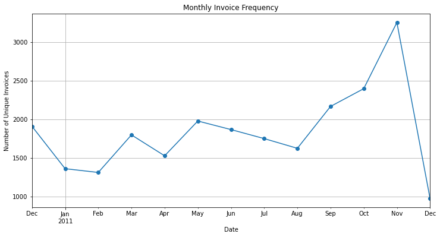

```python
# Resample by month and count the number of invoices
monthly_invoices = df.resample('M', on='InvoiceDate').InvoiceNo.nunique()

plt.figure(figsize=(12, 6))
monthly_invoices.plot(marker='o')
plt.title('Monthly Invoice Frequency')
plt.xlabel('Date')
plt.ylabel('Number of Unique Invoices')
plt.grid(True)
plt.show()
```

November showcased the highest amount of unique invoices which could mean that this was the month that the buying behavoir of customers offered greater variability, maybe due to the beginning of the holiday season that allowed for greater disposable income and greater variability while the other months are not showing great amounts of unique invoices which does not mean that sales were down at that point. It could just mean that customers had a much more stagnant buying behavior.

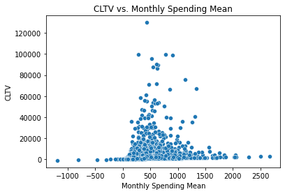

```python
# cltv vs monthly spending
sns.scatterplot(data=customer_data_cleaned, x='Monthly_Spending_Mean', y='CLTV')
plt.title('CLTV vs. Monthly Spending Mean')
plt.xlabel('Monthly Spending Mean')
plt.ylabel('CLTV')
plt.show()
```

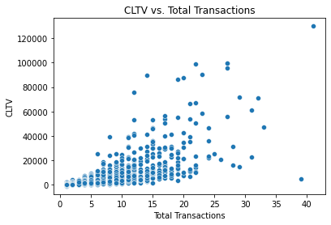

```python
# Cltv vs total transaction
sns.scatterplot(data=customer_data_cleaned, x='Total_Transactions', y='CLTV')
plt.title('CLTV vs. Total Transactions')
plt.xlabel('Total Transactions')
plt.ylabel('CLTV')
plt.show()
```

Most of our clients having a cltv score less than 25000 have made about 1 to 10 transactions. Customers with higher cltv scores have slightly greater amount of transactions which may mean that transactions value in general were much more higher in contrast to the number of transactions.

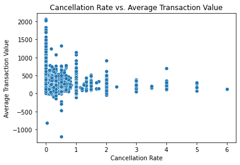

```python
# Cancellation Rate vs. Average Transaction Value

sns.scatterplot(data=customer_data_cleaned, x='Cancellation_Rate', y='Average_Transaction_Value')
plt.title('Cancellation Rate vs. Average Transaction Value')
plt.xlabel('Cancellation Rate')
plt.ylabel('Average Transaction Value')
plt.show()
```

Generally transaction values over 1000 have low to none cancellations, while major number of cancellations happening in average transactions of 0 to 1000. This shows customer values and behavior towards lower values orders. Customers generally do not cancel expensive orders maybe taking more time to think about the product while for lower valued orders customers dont think to seem much and then end up cancelling. This allows for the firm to come up with ways to keep the customer engaged in these lower valued products up until after the cancellation period.

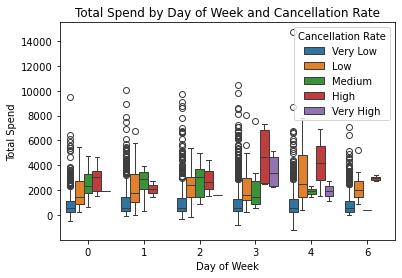

```python
# Total Spending by day of week and cancellation r
customer_data_cleaned['Cancellation_Rate_Binned'] = pd.cut(customer_data_cleaned['Cancellation_Rate'], bins=5, labels=['Very Low', 'Low', 'Medium', 'High', 'Very High'])
sns.boxplot(data=customer_data_cleaned, x='Day_Of_Week', y='Total_Spend', hue='Cancellation_Rate_Binned')
plt.title('Total Spend by Day of Week and Cancellation Rate')
plt.xlabel('Day of Week')
plt.ylabel('Total Spend')
plt.legend(title='Cancellation Rate')
plt.show()
```

```python
customer_data_cleaned
```

|  | CustomerID | Days_Since_Last_Purchase | Total_Transactions | Total_Products_Purchased | Total_Spend | Average_Transaction_Value | Unique_Products_Purchased | Average_Days_Between_Purchases | Day_Of_Week | Hour | ... | Cancellation_Frequency | Cancellation_Rate | Monthly_Spending_Mean | Monthly_Spending_Std | Spending_Trend | Is_UK_y | Purchase_Frequency | Customer_Lifespan | CLTV | Cancellation_Rate_Binned |
| --- | --- | --- | --- | --- | --- | --- | --- | --- | --- | --- | --- | --- | --- | --- | --- | --- | --- | --- | --- | --- | --- |
| 0 | 12346.0 | 325 | 2 | 0 | 0.0 | 0.0 | 1 | 0.0 | 1 | 0 | ... | 1 | 0.5 | 0.0 | 0.0 | 0.0 | 1 | 0.006154 | 325.0 | 0.0 | Very Low |
| 1 | 12347.0 | 2 | 7 | 2458 | 4310.0 | 615.714286 | 103 | 2.016575 | 1 | 0 | ... | 0 | 0.0 | 615.714286 | 341.070789 | 4.486071 | 0 | 1.742779 | 16.116022 | 17293.356259 | Very Low |
| 2 | 12348.0 | 75 | 4 | 2332 | 1437.24 | 359.31 | 21 | 10.884615 | 3 | 0 | ... | 0 | 0.0 | 359.31 | 203.875689 | -100.884 | 0 | 0.046574 | 118.538462 | 1983.687273 | Very Low |
| 3 | 12349.0 | 18 | 1 | 627 | 1442.7 | 1442.7 | 71 | 0.0 | 0 | 0 | ... | 0 | 0.0 | 1442.7 | 0.0 | 0.0 | 0 | 0.055556 | 18.0 | 1442.7 | Very Low |
| 4 | 12350.0 | 310 | 1 | 196 | 294.4 | 294.4 | 16 | 0.0 | 2 | 0 | ... | 0 | 0.0 | 294.4 | 0.0 | 0.0 | 0 | 0.003226 | 310.0 | 294.4 | Very Low |
| ... | ... | ... | ... | ... | ... | ... | ... | ... | ... | ... | ... | ... | ... | ... | ... | ... | ... | ... | ... | ... | ... |
| 4063 | 18280.0 | 277 | 1 | 45 | 180.6 | 180.6 | 10 | 0.0 | 0 | 0 | ... | 0 | 0.0 | 180.6 | 0.0 | 0.0 | 1 | 0.00361 | 277.0 | 180.6 | Very Low |
| 4064 | 18281.0 | 180 | 1 | 44 | 64.32 | 64.32 | 6 | 0.0 | 6 | 0 | ... | 0 | 0.0 | 64.32 | 0.0 | 0.0 | 1 | 0.005556 | 180.0 | 64.32 | Very Low |
| 4065 | 18282.0 | 7 | 3 | 98 | 176.6 | 58.866667 | 12 | 9.916667 | 4 | 0 | ... | 1 | 0.5 | 88.3 | 14.792674 | -20.92 | 1 | 0.17734 | 36.75 | 383.648276 | Very Low |
| 4066 | 18283.0 | 3 | 16 | 1312 | 1956.59 | 122.286875 | 259 | 0.481268 | 3 | 0 | ... | 0 | 0.0 | 195.659 | 156.83062 | 20.20697 | 1 | 4.596026 | 10.700288 | 6013.92274 | Very Low |
| 4067 | 18287.0 | 42 | 3 | 1586 | 1837.28 | 612.426667 | 59 | 2.304348 | 2 | 0 | ... | 0 | 0.0 | 918.64 | 216.883792 | 306.72 | 1 | 0.067713 | 48.913043 | 2028.400393 | Very Low |

4068 rows × 21 columns

### Day of Week analysis

**(Executive Summary I)**

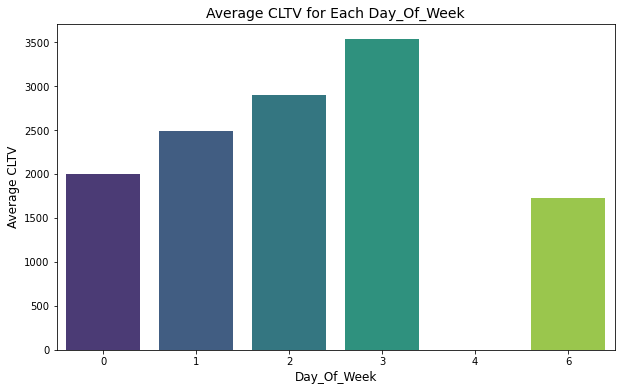

```python
# Calculate the average CLTV for each Day_Of_Week
avg_cltv = customer_data_cleaned.groupby('Day_Of_Week')['CLTV'].mean().reset_index()

# Plot the bar graph
plt.figure(figsize=(10, 6))
sns.barplot(x='Day_Of_Week', y='CLTV', data=avg_cltv, palette='viridis')

# Add titles and labels
plt.title('Average CLTV for Each Day_Of_Week', fontsize=14)
plt.xlabel('Day_Of_Week', fontsize=12)
plt.ylabel('Average CLTV', fontsize=12)

plt.show()
```

# 7. CORRELATION ANALYSIS

Before we start with KMeans clustering, we need to check if any features in our dataset are highly correlated with each other. When features are too similar, it can confuse the clustering process and lead to less meaningful results.

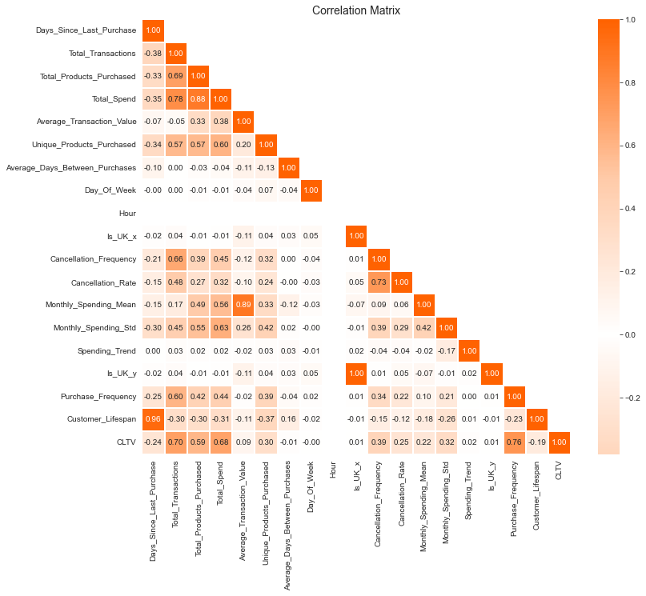

```python
# Reset background style
sns.set_style('whitegrid')

#Extracting non numeric columns for proper use later on
non_numeric_columns = customer_data_cleaned.select_dtypes(exclude=[np.number]).columns

# Calculate the correlation matrix excluding the 'CustomerID' column
corr = customer_data_cleaned.drop(columns=['CustomerID'] + list(non_numeric_columns)).corr()

# Define a custom colormap
colors = ['#ff6200', '#ffcaa8', 'white', '#ffcaa8', '#ff6200']
my_cmap = LinearSegmentedColormap.from_list('custom_map', colors, N=256)

# Create a mask to only show the lower triangle of the matrix (since it's mirrored around its
# top-left to bottom-right diagonal)
mask = np.zeros_like(corr)
mask[np.triu_indices_from(mask, k=1)] = True

# Plot the heatmap
plt.figure(figsize=(12, 10))
sns.heatmap(corr, mask=mask, cmap=my_cmap, annot=True, center=0, fmt='.2f', linewidths=2)
plt.title('Correlation Matrix', fontsize=14)
plt.show()
```

The heatmap shows that some of our features are strongly correlated with each other, such as:

Monthly_Spending_Mean and Average_Transaction_Value  
Total_Spend and Total_Products_Purchased  
Total_Transactions and Total_Spend  
Cancellation_Rate and Cancellation_Frequency

# Relation between day of the week and Average CLTV

**(Executive Summary I)**

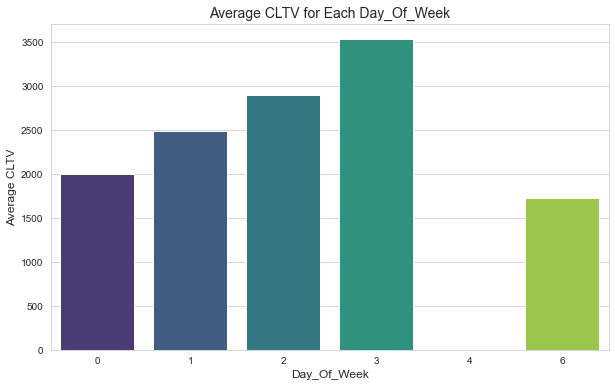

```python
# Calculate the average CLTV for each Day_Of_Week
avg_cltv = customer_data_cleaned.groupby('Day_Of_Week')['CLTV'].mean().reset_index()

# Plot the bar graph
plt.figure(figsize=(10, 6))
sns.barplot(x='Day_Of_Week', y='CLTV', data=avg_cltv, palette='viridis')

# Add titles and labels
plt.title('Average CLTV for Each Day_Of_Week', fontsize=14)
plt.xlabel('Day_Of_Week', fontsize=12)
plt.ylabel('Average CLTV', fontsize=12)

plt.show()
```